# Simulations_v2

Estimation of panel regressions with time-invariant variables

1 Introduction

2 I. The Data Generating Processes

2.1 1. A simple version to begin with : DGP0

2.2 2. Pesaran's DGP1 : exogenous TIV

2.3 3. Pesaran's DGP2 : TIV correlated with FE

2.4 4.DGP3 : correlation of the TIVS together and the FE

3 II. Estimators

3.1 1. Naive method : Fixed Effects Vector Decomposition (FEVD) - (Plümper and Troeger 2007)

3.2 2. Fixed Effects Filtered - FEF (Pesaran and Zhou, 2014)

3.3 3. One-step estimation : Untangling Fixed Effects - UFE (Teulings, Klaassen, and others 2016)

3.3.1 Untangling Normalisation

3.3.2 Construction of $N^u$

4 III. Monte Carlo Simulations

4.1 1. Replications

4.2 2. Analysis

4.2.1 a. Simple DGP

4.2.2 (i) UFE and FEF are the same

4.2.3 (ii) Comparison of FEF and FEVD

4.2.4 b. Comparison of FEF and FEVD with Pesaran's DGP in the case of normal errors (case 1)

4.2.5 c. Comparison of FEF and FEVD with Pesaran's DGP in the case of heteroskedastic errors (case 2)

4.2.6 d. Comparison of FEF and FEVD with Pesaran's DGP in the case of heteroskedastic and serially correlated errors (case 3)

4.2.7 e. Comparison of FEF, FEVD, and FEVD with an intercept (Pesarans's DGP - case 1)

4.2.8 f. Dynamic DGP

4.2.8.1 DGP1, case 1

4.2.8.2 DGP1, case 2

4.2.8.3 DGP1, case 3

5 IV. Application to real data

5.1 1. Application of the FEF and FEVD estimators to real data

5.1.1 2. UFE = FEF ?

5.1.1.1 DGP 1

5.1.1.2 DGP 2

5.1.1.3 DGP 3

5.1.1.4 DGP3 + extra variations

5.1.1.5 With real data

5.2 2. Comparison of out-of-sample goodness-of-fit

6 (Preliminary) Conclusion

7 Bibliography

```r
options(repr.plot.width=5, repr.plot.height=4)
#install.packages('ggplot2', repos='http://cran.rstudio.com/')
#install.packages('reshape', repos='http://cran.rstudio.com/')
#install.packages('reshape2', repos='http://cran.rstudio.com/')
#install.packages('plotly', repos='http://cran.rstudio.com/')
#install.packages('plm', repos='http://cran.rstudio.com/')
#install.packages('gridExtra', repos='http://cran.rstudio.com/')
library('plm')
library('ggplot2')
library('plotly')
library('reshape2')
require(gridExtra)



Sys.setenv("plotly_username"="NicolasWoloszko")
Sys.setenv("plotly_api_key"="Rq01zHODMCjSxOiI6EsX")

options(repr.plot.width=8, repr.plot.height=4)

describe_data=function(results){
    sequence_N=unique(results$N)
    sequence_T=unique(results$T)
    replications=dim(results)[1]/(length(sequence_N)*length(sequence_T))
    cat("The Monte Carlo Simulations replicated",replications, "times the data and estimations for every (N, T) couple with N in", sequence_N, "and T in", sequence_T )
}

display=function(p2, with_plotly, title){
    options(repr.plot.width=8, repr.plot.height=4)
    p2=p2+theme(legend.position = "right", legend.title=element_blank(), axis.text.x = element_text(angle=45), plot.title = element_text(hjust = 0.5, size=10, , family="Helvetica"))
    if (with_plotly){
        gg <- ggplotly(p2)
        chart_link12 = plotly_POST(gg, filename=title)
    }else {
        return(p2+ggtitle(title))
    }
}

display_bias_ratio=function(results, gamma, title, with_plotly){
    results$bias_fevd=abs(results$FEVD-gamma)
    results$bias_fef=abs(results$FEF-gamma)
    results$bias_ratio=results$bias_fef/results$bias_fevd
    results_agr=aggregate(bias_ratio~N+T, data=results, mean, na.rm=TRUE)
    p2=ggplot(data=results_agr, aes(x=N, y=bias_ratio))+ geom_hline(yintercept=1)+geom_point(size=1)+geom_line()+ facet_grid(. ~ T)
    display(p2, with_plotly=with_plotly, title=title)
}


display_mse_ratio=function(results, gamma, title, with_plotly){
    results$var_fevd=abs(results$FEVD-gamma)^2
    results$var_fef=abs(results$FEF-gamma)^2
    var_table=aggregate(cbind(var_fevd,var_fef)~N+T, data=results, mean, na.rm=TRUE)
    var_table$mse_ratio=var_table$var_fef/var_table$var_fevd
    p2=ggplot(data=var_table, aes(x=N, y=mse_ratio))+ geom_hline(yintercept=1)+geom_point(size=1)+geom_line()+ facet_grid(. ~ T)
    display(p2, with_plotly=with_plotly, title=title)
}

display_mse=function(results, gamma, title, with_plotly){
    results$mse_fevd=(results$FEVD-gamma)^2
    results$mse_fef=(results$FEF-gamma)^2
    mse_table=aggregate(cbind(mse_fevd,mse_fef)~N+T, data=results, mean, na.rm=TRUE)
    mse_table_long <- melt(mse_table, id=c("N", 'T'))  # convert to long format
    colnames(mse_table_long)[4] <- "MSE"
    p2=ggplot(data=mse_table_long, aes(x=N, y=MSE, colour=variable))+geom_point(size=1)+geom_line()+ facet_grid(. ~ T)
    display(p2, with_plotly=with_plotly, title=title)
}

display_bias=function(results, gamma, title, with_plotly){
    results$bias_fevd=abs(results$FEVD-gamma)
    results$bias_fef=abs(results$FEF-gamma)
    mse_table=aggregate(cbind(bias_fevd,bias_fef)~N+T, data=results, mean, na.rm=TRUE)
    mse_table_long <- melt(mse_table, id=c("N", 'T'))  # convert to long format
    colnames(mse_table_long)[4] <- "Bias"
    p2=ggplot(data=mse_table_long, aes(x=N, y=Bias, colour=variable))+geom_point(size=1)+geom_line()+ facet_grid(. ~ T) #+ theme_bw()
    display(p2, with_plotly=with_plotly, title=title)
}

display_mse_three=function(results, gamma, title){
    results$mse_fevd=abs(results$FEVD-gamma)^2
    results$mse_fef=abs(results$FEF-gamma)^2
    results$mse_fevd_with=abs(results$FEVD_with-gamma)^2
    mse_table=aggregate(cbind(mse_fevd,mse_fef, mse_fevd_with)~N+T, data=results, mean, na.rm=TRUE)
    mse_table_long <- melt(mse_table, id=c("N", 'T'))  # convert to long format
    p2=ggplot(data=mse_table_long, aes(x=N, y=value, colour=variable))+geom_point(size=1)+geom_line()+ facet_grid(. ~ T) #+ theme_bw()
    #print(p2)
    gg <- ggplotly(p2)
    chart_link12 = plotly_POST(gg, filename=title)
    return(mse_table)
}

display_mse_three=function(results, gamma, title, with_plotly){
    results$mse_fevd=abs(results$FEVD-gamma)^2
    results$mse_fef=abs(results$FEF-gamma)^2
    results$mse_fevd_with=abs(results$FEVD_with-gamma)^2
    mse_table=aggregate(cbind(mse_fevd,mse_fef, mse_fevd_with)~N+T, data=results, mean, na.rm=TRUE)
    mse_table_long <- melt(mse_table, id=c("N", 'T'))  # convert to long format
    p2=ggplot(data=mse_table_long, aes(x=N, y=value, colour=variable))+geom_point(size=1)+geom_line()+ facet_grid(. ~ T) #+ theme_bw()
    display(p2, with_plotly=with_plotly, title=title)
    #return(mse_table)
}
```

# Introduction

The following notebook aims at comparing various estimators of time-invariant variables in panel data settings. First, we compare two two-step estimators :

- the Fixed Effects Vector Decomposition (FEVD) by Plumper and Troeger, that is much criticized by Greene as a 'naïve' estimator
- the Fixed Effects Filtered (FEF) estimator, by Pesaran and Zhou, is supposed to have better asymptotic properties than the FEVD, as shown by the Monte Carlo simulations performed by the authors.

Second, we introduce a one-step estimator, the Untangling Fixed Effects estimator (UFE), by Teulings and Klaassen.

# I. The Data Generating Processes

## 1. A simple version to begin with : DGP0

##### The model

$$y_{it} = \alpha_i + x_{1, it} \beta_1+ x_{2, it} \beta_2 +z_{i} \gamma+ \epsilon_{it}$$

With
$$\epsilon_{it} \sim \mathcal{N}(0, \sigma^2)$$

##### Time-varying regressors :

$$x_{1, it} = 1 + \alpha_i g_{1,t} + \omega_{it,1}$$$$x_{2, it} = 1 + \alpha_i g_{2,t} + \omega_{it,2}$$

$$\omega_{it,j} = \mu_{ij} + \rho_{ij} \omega_{it-1,j} \text{, for }j=1,2 $$

$$\mu_{ij} \sim \mathcal{N}(0,2)$$ $$\rho_{ij} \sim U[0, 0.98] $$

##### Time-invariant covariates :

- First step : $z_{it} \sim U[0,1]$
- Second step : $z_{it}$ is an ordered combination of U[0,1] so as to resemble decreasing stairs
- Third step : $z_{it}$ is simulated by inversing the empirical distribution function

```r
DGP=function(N, T, beta1, beta2, gamma){
    country=rep(1:N, each=T)
    z=rep(runif(N, 0, 1), each=T)
    alpha_bycountry=rnorm(N, 0, 0.1)
    alpha=rep(alpha_bycountry, each=T)

    z_bar_bycountry=aggregate(z,by=list(country), mean)
    z_bar=rep(z_bar_bycountry[,2], each=T)

    mu_bycountry1=rnorm(N, 0, 2)
    rho_bycountry1=runif(N, 0, 0.98)

    mu_bycountry2=rnorm(N, 0, 2)
    rho_bycountry2=runif(N, 0, 0.98)

    generate_omega<-function(rho, mu){
        return(arima.sim(model=list(ar=c(rho)),innov = rep(mu, T), n=T))
    } #AR(1) with a constant innovation varying across countries

    omega1= as.vector(mapply(generate_omega, rho_bycountry1, mu_bycountry1))#mapply returns a matrix whose columns we stack in a single vector
    omega2= as.vector(mapply(generate_omega, rho_bycountry2, mu_bycountry2))

    g_byyear=runif(T, 0, 2)
    g=unlist(rep(list(g_byyear), N))

    x1=1 + alpha*g + omega1
    x2=1 + alpha*g + omega2

    epsilon=rnorm(N*T, 0, 3)

    y=alpha + x1*beta1 + x2*beta2 +z*gamma+ epsilon
    #print(length(alpha))
    #print(length(x1))
    years=rep(1:T, N)
    d=cbind(country, years, y, x1, x2,z, alpha, epsilon)
    d=as.data.frame(d)

    data=pdata.frame(d, c("country","years"))
    return(data)
}

N=50
T=30
d=DGP(N=N, T=T, beta1=1.5, beta2=0.5, gamma=0.7)
```

```r
data=pdata.frame(d, c("country","years"))#, drop = TRUE)
head(data)
```

[output not shown]

```r
ts.plot(matrix(d$y, ncol=N))
```

[output not shown]

Plot of x1, x2, and z

```r
options(repr.plot.width=8, repr.plot.height=4)

par(mfrow=c(1,2))
ts.plot(matrix(d$x1, ncol=N))
ts.plot(matrix(d$x2, ncol=N))
ts.plot(matrix(d$z, ncol=N))
```

[output not shown]

## 2. Pesaran's DGP1 : exogenous TIV

```r
#Function coding

extract_subsets=function(x1, T){
    X1=list()
    for (i in 0:(N-1)){
    #print(i*T+1)
    #print(((i+1)*T))
    X1[[i+1]]=(x1[(i*T+1):((i+1)*T)])
}
    return(X1)
}

DGP1=function(N, T, beta1, beta2, gamma1, gamma2,theta, case, dynamic){
    country=rep(1:N, each=T)
    z1=rep(1+rnorm(N, 0, 1), each=T)
    z2=rep(runif(N, 7, 12), each=T)

    alpha_bycountry=0.5*(rchisq(N, 2)-2)
    alpha=rep(alpha_bycountry, each=T)

    #z_bar_bycountry=aggregate(z,by=list(country), mean)
    #z_bar=rep(z_bar_bycountry[,2], each=T)

    mu_bycountry1=rnorm(N, 0, 2)
    rho_bycountry1=runif(N, 0, 0.98)

    mu_bycountry2=rnorm(N, 0, 2)
    rho_bycountry2=runif(N, 0, 0.98)

    sigma=0.5*(1+0.5*rchisq(N, 2))

    epsi1=rnorm(N, 0, sigma)
    epsi2=rnorm(N, 0, sigma)

    omega_zero1_bycountry=rnorm(N, mu_bycountry1, sigma)
    omega_zero2_bycountry=rnorm(N, mu_bycountry2, sigma)

    generate_omega<-function(rho, mu, epsi, start){
        vecteur_innovation=mu*(1-rho)+sqrt(1-rho^2)*epsi
        return(arima.sim(model=list(ar=c(rho)),innov = rep(vecteur_innovation, T),start.innov=start, n.start=1, n=T))
    }

    #attention epsi 1 ou epsi2 !!!!!
    omega1= as.vector(mapply(generate_omega, rho_bycountry1, mu_bycountry1, epsi1, omega_zero1_bycountry))#mapply returns a matrix whose columns we stack in a single vector
    omega2= as.vector(mapply(generate_omega, rho_bycountry2, mu_bycountry2, epsi2, omega_zero2_bycountry))

    g1_byyear=runif(T, 0, 2)
    g1=unlist(rep(list(g1_byyear), N))

    g2_byyear=runif(T, 0, 2)
    g2=unlist(rep(list(g2_byyear), N))

    x1=1 + alpha*g1 + omega1
    x2=1 + alpha*g2 + omega2

    if (case==1){
        epsilon=rnorm(N*T, 0, 1)
    }

    if (case==2){
        epsilon=as.vector(mapply((function (x) rnorm(T, 0, x)), sigma))
    }

    if (case==3){
        rho=runif(N, 0, 0.98)
        sig=0.5*(1+0.5*rchisq(N, 2))
        nu=rnorm(N, 0, sig)
        generate_epsilon<-function(rho, sig, nu){
            vecteur_innovation=nu*sqrt(1-rho^2)
            return(arima.sim(model=list(ar=c(rho)),innov = rep(vecteur_innovation, T),start.innov=0, n.start=1, n=T))
            }
        epsilon=as.vector(mapply(generate_epsilon, rho, sig, nu))
    }

    if (dynamic){
        vecteur_innovation=x1*beta1 + x2*beta2 +z1*gamma1+z2*gamma2+ epsilon#doit être de taille T

        generate_y<-function(theta, vecteur_innovation , start){
            #vecteur_innovation=extract_subsets(vecteur_innovation, T)
            return(arima.sim(model=list(ar=c(theta)),innov = vecteur_innovation,start.innov=start, n.start=1, n=T))
        }
        vecteur_innovation=extract_subsets(vecteur_innovation, T)
        y= lapply(vecteur_innovation, function(u) generate_y(theta=theta, vecteur_innovation = unlist(u) , start=0))
        y=unlist(y)

    } else {
        y=alpha + x1*beta1 + x2*beta2 +z1*gamma1+z2*gamma2+ epsilon

    }

    #y=alpha + x1*beta1 + x2*beta2 +z1*gamma1+z2*gamma2+ epsilon
    #print(length(alpha))
    #print(length(x1))
    years=rep(1:T, N)
    d=cbind(country, years, y, x1, x2,z1, z2, alpha, epsilon)
    d=as.data.frame(d)

    #data=pdata.frame(d, c("country","years"))
    return(d)
}

d=DGP1(N=50, T=30, beta1=1, beta2=1, gamma=1, gamma2=1,theta=0.8, case=1, dynamic=TRUE)
```

```r
DGP1(N=5, T=4, beta1=1, beta2=1, gamma=1, gamma2=1,theta=0.8, case=1, dynamic=TRUE)
```

| country | years | y | x1 | x2 | z1 | z2 | alpha | epsilon |
| --- | --- | --- | --- | --- | --- | --- | --- | --- |
| 1 | 1 | 7.700404 | -0.3027916 | 1.148067992 | 1.0226025 | 8.671438 | 1.36547112 | -2.83891324 |
| 1 | 2 | 19.509047 | 0.2075512 | 2.996762707 | 1.0226025 | 8.671438 | 1.36547112 | 0.45036884 |
| 1 | 3 | 26.566228 | -0.6428466 | 3.428672223 | 1.0226025 | 8.671438 | 1.36547112 | -1.52087617 |
| 1 | 4 | 34.427752 | 0.9310570 | 3.611441664 | 1.0226025 | 8.671438 | 1.36547112 | -1.06177007 |
| 2 | 1 | 15.090362 | -1.0274218 | 3.116576403 | 0.8037644 | 11.949139 | -0.80719770 | 0.24830373 |
| 2 | 2 | 25.633246 | -1.6154027 | 3.154842278 | 0.8037644 | 11.949139 | -0.80719770 | -0.73138712 |
| 2 | 3 | 37.268769 | -1.2400972 | 3.634717799 | 0.8037644 | 11.949139 | -0.80719770 | 1.61464802 |
| 2 | 4 | 45.513039 | -2.2272017 | 4.004935570 | 0.8037644 | 11.949139 | -0.80719770 | 1.16738613 |
| 3 | 1 | 13.671493 | 0.9243095 | 0.596259705 | 1.2091490 | 10.783186 | -0.64328378 | 0.15858844 |
| 3 | 2 | 24.833001 | 1.4887656 | -0.006081626 | 1.2091490 | 10.783186 | -0.64328378 | 0.42078692 |
| 3 | 3 | 34.931633 | 2.1344149 | -0.086128220 | 1.2091490 | 10.783186 | -0.64328378 | 1.02461022 |
| 3 | 4 | 41.069862 | 1.4712688 | -0.103584151 | 1.2091490 | 10.783186 | -0.64328378 | -0.23546407 |
| 4 | 1 | 10.555114 | -1.8265990 | 2.320303346 | -0.1564057 | 9.281057 | -0.25596497 | 0.93675810 |
| 4 | 2 | 17.937371 | -2.0329726 | 2.365576107 | -0.1564057 | 9.281057 | -0.25596497 | 0.03602508 |
| 4 | 3 | 25.235986 | -1.9721607 | 2.581137427 | -0.1564057 | 9.281057 | -0.25596497 | 1.15246158 |
| 4 | 4 | 28.701227 | -2.3464610 | 2.771461794 | -0.1564057 | 9.281057 | -0.25596497 | -1.03721356 |
| 5 | 1 | 11.776189 | -0.5851904 | 1.353870458 | 2.2829811 | 10.930239 | 0.06558427 | -2.20571106 |
| 5 | 2 | 22.032672 | -0.9767555 | 1.723779315 | 2.2829811 | 10.930239 | 0.06558427 | -1.34852293 |
| 5 | 3 | 32.115088 | -1.1426323 | 1.915120831 | 2.2829811 | 10.930239 | 0.06558427 | 0.50324136 |
| 5 | 4 | 40.007949 | -1.1049430 | 2.027330291 | 2.2829811 | 10.930239 | 0.06558427 | 0.18027105 |

```r
#Function coding
N=5
T=4
case=1
dynamic=TRUE

country=rep(1:N, each=T)
z1=rep(1+rnorm(N, 0, 1), each=T)
z2=rep(runif(N, 7, 12), each=T)

alpha_bycountry=0.5*(rchisq(N, 2)-2)
alpha=rep(alpha_bycountry, each=T)

#z_bar_bycountry=aggregate(z,by=list(country), mean)
#z_bar=rep(z_bar_bycountry[,2], each=T)

mu_bycountry1=rnorm(N, 0, 2)
rho_bycountry1=runif(N, 0, 0.98)

mu_bycountry2=rnorm(N, 0, 2)
rho_bycountry2=runif(N, 0, 0.98)

sigma=0.5*(1+0.5*rchisq(N, 2))

epsi1=rnorm(N, 0, sigma)
epsi2=rnorm(N, 0, sigma)

omega_zero1_bycountry=rnorm(N, mu_bycountry1, sigma)
omega_zero2_bycountry=rnorm(N, mu_bycountry2, sigma)

generate_omega<-function(rho, mu, epsi, start){
    vecteur_innovation=mu*(1-rho)+sqrt(1-rho^2)*epsi
    return(arima.sim(model=list(ar=c(rho)),innov = rep(vecteur_innovation, T),start.innov=start, n.start=1, n=T))
}

#attention epsi 1 ou epsi2 !!!!!
omega1= as.vector(mapply(generate_omega, rho_bycountry1, mu_bycountry1, epsi1, omega_zero1_bycountry))#mapply returns a matrix whose columns we stack in a single vector
omega2= as.vector(mapply(generate_omega, rho_bycountry2, mu_bycountry2, epsi2, omega_zero2_bycountry))

g1_byyear=runif(T, 0, 2)
g1=unlist(rep(list(g1_byyear), N))

g2_byyear=runif(T, 0, 2)
g2=unlist(rep(list(g2_byyear), N))

x1=1 + alpha*g1 + omega1
x2=1 + alpha*g2 + omega2

if (case==1){
    epsilon=rnorm(N*T, 0, 1)
}

if (case==2){
    epsilon=as.vector(mapply((function (x) rnorm(T, 0, x)), sigma))
}

if (case==3){
    rho=runif(N, 0, 0.98)
    sig=0.5*(1+0.5*rchisq(N, 2))
    nu=rnorm(N, 0, sig)
    generate_epsilon<-function(rho, sig, nu){
        vecteur_innovation=nu*sqrt(1-rho^2)
        return(arima.sim(model=list(ar=c(rho)),innov = rep(vecteur_innovation, T),start.innov=0, n.start=1, n=T))
        }
    epsilon=as.vector(mapply(generate_epsilon, rho, sig, nu))
}

if (dynamic){
    vecteur_innovation=x1*beta1 + x2*beta2 +z1*gamma1+z2*gamma2+ epsilon#doit être de taille T

    generate_y<-function(theta, vecteur_innovation , start){
        #vecteur_innovation=extract_subsets(vecteur_innovation, T)
        return(arima.sim(model=list(ar=c(theta)),innov = vecteur_innovation,start.innov=start, n.start=1, n=T))
    }
    vecteur_innovation=extract_subsets(vecteur_innovation, T)
    y= lapply(vecteur_innovation, function(u) generate_y(theta=theta, vecteur_innovation = unlist(u) , start=0))
    y=unlist(y)

} else {
    y=alpha + x1*beta1 + x2*beta2 +z1*gamma1+z2*gamma2+ epsilon

}

#y=alpha + x1*beta1 + x2*beta2 +z1*gamma1+z2*gamma2+ epsilon
#print(length(alpha))
#print(length(x1))
years=rep(1:T, N)
d=cbind(country, years, y, x1, x2,z1, z2, alpha, epsilon)
d=as.data.frame(d)

#data=pdata.frame(d, c("country","years"))


d
```

| country | years | y | x1 | x2 | z1 | z2 | alpha | epsilon |
| --- | --- | --- | --- | --- | --- | --- | --- | --- |
| 1 | 1 | 16.296448 | 4.29115348 | 0.4678879 | 1.1291079 | 10.562256 | -0.8318648 | -0.15395678 |
| 1 | 2 | 25.163334 | 4.15075591 | 1.5629864 | 1.1291079 | 10.562256 | -0.8318648 | -0.38999581 |
| 1 | 3 | 29.020740 | 4.76018869 | 0.3269930 | 1.1291079 | 10.562256 | -0.8318648 | -0.33947231 |
| 1 | 4 | 31.514259 | 4.68399160 | 0.9591662 | 1.1291079 | 10.562256 | -0.8318648 | -0.33063211 |
| 2 | 1 | 14.654724 | 2.15917022 | 4.1739400 | -0.6110143 | 8.983640 | 1.7511279 | -0.05101229 |
| 2 | 2 | 20.020143 | 2.21025673 | 2.1685523 | -0.6110143 | 8.983640 | 1.7511279 | -0.05865361 |
| 2 | 3 | 23.172722 | 0.65659148 | 4.9805773 | -0.6110143 | 8.983640 | 1.7511279 | -0.84714458 |
| 2 | 4 | 24.759745 | 0.53122143 | 3.7971526 | -0.6110143 | 8.983640 | 1.7511279 | 0.47238466 |
| 3 | 1 | 6.154798 | 0.05855587 | -0.5756012 | 0.3005233 | 7.050612 | 0.2556878 | -0.67929216 |
| 3 | 2 | 8.856403 | -0.16043782 | -1.4673499 | 0.3005233 | 7.050612 | 0.2556878 | 0.05565594 |
| 3 | 3 | 10.560224 | -0.44403061 | -1.1879155 | 0.3005233 | 7.050612 | 0.2556878 | 0.41283339 |
| 3 | 4 | 10.573605 | -0.48498071 | -1.3894332 | 0.3005233 | 7.050612 | 0.2556878 | -0.18322845 |
| 4 | 1 | 9.164920 | -0.46697123 | -2.9470066 | 1.1552567 | 11.747234 | -0.3990044 | -0.32359310 |
| 4 | 2 | 14.537568 | -0.24191677 | -3.6907093 | 1.1552567 | 11.747234 | -0.3990044 | 0.98524340 |
| 4 | 3 | 16.424756 | 0.27024182 | -4.7342133 | 1.1552567 | 11.747234 | -0.3990044 | 0.71745238 |
| 4 | 4 | 16.533552 | 0.40485356 | -4.5996752 | 1.1552567 | 11.747234 | -0.3990044 | -0.38649490 |
| 5 | 1 | 6.771654 | -4.05729944 | -1.8413899 | 2.1165035 | 9.213908 | -0.7408433 | 1.33993143 |
| 5 | 2 | 10.079957 | -3.31521776 | -0.8860712 | 2.1165035 | 9.213908 | -0.7408433 | -0.43499286 |
| 5 | 3 | 10.418884 | -2.06032441 | -2.0156577 | 2.1165035 | 9.213908 | -0.7408433 | -1.87552373 |
| 5 | 4 | 12.872359 | -1.53956877 | -1.4812136 | 2.1165035 | 9.213908 | -0.7408433 | -0.64671255 |

Plot of y

[figure not shown]

```r
N=50
T=30

options(repr.plot.width=8, repr.plot.height=9)
par(mfrow=c(3,3))

d=DGP1(N=N, T=T, beta1=1, beta2=1, gamma=1, gamma2=1,theta=0.1, case=1, dynamic=FALSE)
ts.plot(matrix(d$y, ncol=N), main="Static Model, case 1")

d=DGP1(N=N, T=T, beta1=1, beta2=1, gamma=1, gamma2=1,theta=0.1, case=1, dynamic=FALSE)
ts.plot(matrix(d$y, ncol=N), main="Statitc Model, case 2")

d=DGP1(N=N, T=T, beta1=1, beta2=1, gamma=1, gamma2=1,theta=0.1, case=1, dynamic=FALSE)
ts.plot(matrix(d$y, ncol=N), main="Static Model, case 3")

d=DGP1(N=N, T=T, beta1=1, beta2=1, gamma=1, gamma2=1,theta=0.1, case=1, dynamic=TRUE)
ts.plot(matrix(d$y, ncol=N), main="Dyamic Model, Theta=0.1, case 1")

d=DGP1(N=N, T=T, beta1=1, beta2=1, gamma=1, gamma2=1,theta=0.1, case=2, dynamic=TRUE)
ts.plot(matrix(d$y, ncol=N), main="Dyamic Model, Theta=0.1, case 2")

d=DGP1(N=N, T=T, beta1=1, beta2=1, gamma=1, gamma2=1,theta=0.1, case=3, dynamic=TRUE)
ts.plot(matrix(d$y, ncol=N), main="Dyamic Model, Theta=0.1, case 3")

d=DGP1(N=N, T=T, beta1=1, beta2=1, gamma=1, gamma2=1,theta=0.8, case=1, dynamic=TRUE)
ts.plot(matrix(d$y, ncol=N), main="Dyamic Model, Theta=0.8, case 1")

d=DGP1(N=N, T=T, beta1=1, beta2=1, gamma=1, gamma2=1,theta=0.8, case=2, dynamic=TRUE)
ts.plot(matrix(d$y, ncol=N), main="Dyamic Model, Theta=0.8, case 2")

d=DGP1(N=N, T=T, beta1=1, beta2=1, gamma=1, gamma2=1,theta=0.8, case=3, dynamic=TRUE)
ts.plot(matrix(d$y, ncol=N), main="Dyamic Model, Theta=0.8, case 3")
```

Plot of x1 and x2 ; z1 and z2

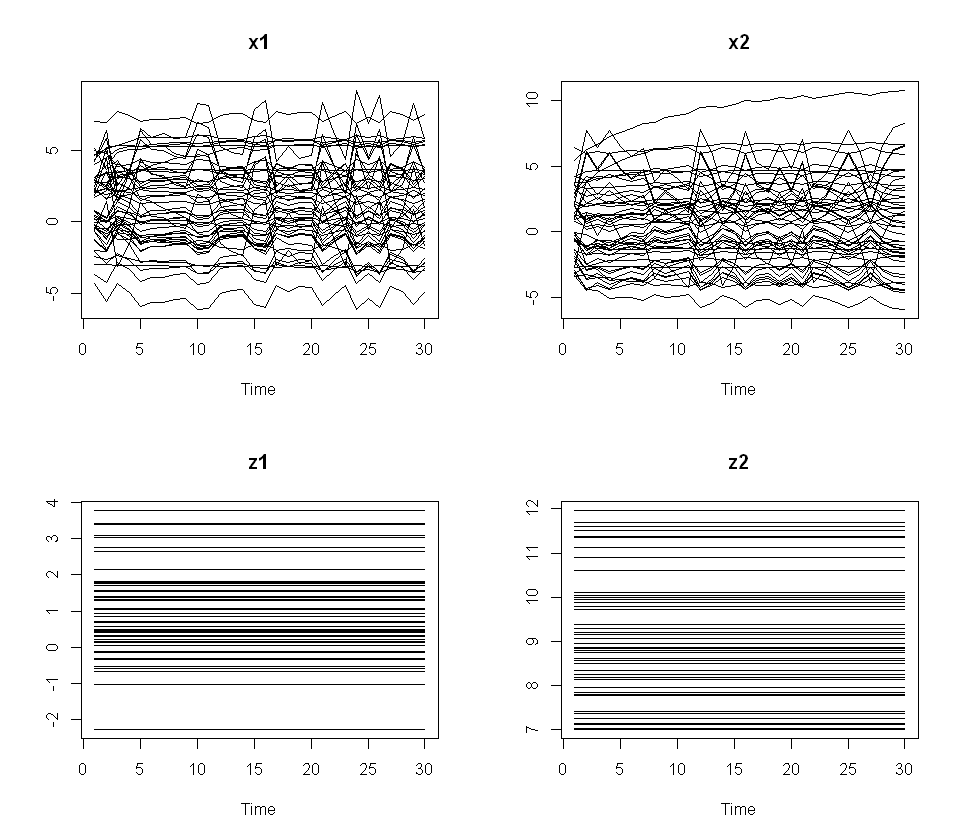

```r
options(repr.plot.width=8, repr.plot.height=7)
par(mfrow=c(2,2))
ts.plot(matrix(d$x1, ncol=N), main="x1")
ts.plot(matrix(d$x2, ncol=N), main="x2")
ts.plot(matrix(d$z1, ncol=N), main="z1")
ts.plot(matrix(d$z2, ncol=N), main="z2")
```

## 3. Pesaran's DGP2 : TIV correlated with FE

```r
#Function coding
DGP2=function(N, T, beta1, beta2, gamma1, gamma2, case){
    country=rep(1:N, each=T)
    z1=rep(1+rnorm(N, 0, 1), each=T)
    #z2=rep(runif(N, 7, 12), each=T)

    alpha_bycountry=0.5*(rchisq(N, 2)-2)
    alpha=rep(alpha_bycountry, each=T)

    z2_bycountry=runif(N, 7, 12)+alpha_bycountry
    z2=rep(z2_bycountry, each=T)

    #z_bar_bycountry=aggregate(z,by=list(country), mean)
    #z_bar=rep(z_bar_bycountry[,2], each=T)

    mu_bycountry1=rnorm(N, 0, 2)
    rho_bycountry1=runif(N, 0, 0.98)

    mu_bycountry2=rnorm(N, 0, 2)
    rho_bycountry2=runif(N, 0, 0.98)

    sigma=0.5*(1+0.5*rchisq(N, 2))

    epsi1=rnorm(N, 0, sigma)
    epsi2=rnorm(N, 0, sigma)

    omega_zero1_bycountry=rnorm(N, mu_bycountry1, sigma)
    omega_zero2_bycountry=rnorm(N, mu_bycountry2, sigma)

    generate_omega<-function(rho, mu, epsi, start){
        vecteur_innovation=mu*(1-rho)+sqrt(1-rho^2)*epsi
        return(arima.sim(model=list(ar=c(rho)),innov = rep(vecteur_innovation, T),start.innov=start, n.start=1, n=T))
    }

    #attention epsi 1 ou epsi2 !!!!!
    omega1= as.vector(mapply(generate_omega, rho_bycountry1, mu_bycountry1, epsi1, omega_zero1_bycountry))#mapply returns a matrix whose columns we stack in a single vector
    omega2= as.vector(mapply(generate_omega, rho_bycountry2, mu_bycountry2, epsi2, omega_zero2_bycountry))

    g1_byyear=runif(T, 0, 2)
    g1=unlist(rep(list(g1_byyear), N))

    g2_byyear=runif(T, 0, 2)
    g2=unlist(rep(list(g2_byyear), N))

    x1=1 + alpha*g1 + omega1
    x2=1 + alpha*g2 + omega2

    if (case==1){
        epsilon=rnorm(N*T, 0, 1)
    }

    if (case==2){
        epsilon=as.vector(mapply((function (x) rnorm(T, 0, x)), sigma))
    }

    if (case==3){
        rho=runif(N, 0, 0.98)
        sig=0.5*(1+0.5*rchisq(N, 2))
        nu=rnorm(N, 0, sig)
        generate_epsilon<-function(rho, sig, nu){
            vecteur_innovation=nu*sqrt(1-rho^2)
            return(arima.sim(model=list(ar=c(rho)),innov = rep(vecteur_innovation, T),start.innov=0, n.start=1, n=T))
            }
        epsilon=as.vector(mapply(generate_epsilon, rho, sig, nu))
    }

    y=alpha + x1*beta1 + x2*beta2 +z1*gamma1+z2*gamma2+ epsilon
    #print(length(alpha))
    #print(length(x1))
    years=rep(1:T, N)
    d=cbind(country, years, y, x1, x2,z1, z2, alpha, epsilon)
    d=as.data.frame(d)

    #data=pdata.frame(d, c("country","years"))
    return(d)
}

d=DGP2(N=50, T=30, beta1=1, beta2=1, gamma=1, gamma2=1, case=3)
```

## 4.DGP3 : correlation of the TIVS together and the FE

```r
#Function coding
DGP3=function(N, T, beta1, beta2, gamma1, gamma2, case){
    country=rep(1:N, each=T)

    alpha_bycountry=0.5*(rchisq(N, 2)-2)
    alpha=rep(alpha_bycountry, each=T)

    z1_bycountry=1+rnorm(N, 0, 1)+0.3*alpha_bycountry
    z1=rep(z1_bycountry, each=T)
    #z2=rep(runif(N, 7, 12), each=T)

    z2_bycountry=runif(N, 7, 12)+alpha_bycountry+(z1_bycountry)
    z2=rep(z2_bycountry, each=T)

    #z_bar_bycountry=aggregate(z,by=list(country), mean)
    #z_bar=rep(z_bar_bycountry[,2], each=T)

    mu_bycountry1=rnorm(N, 0, 2)
    rho_bycountry1=runif(N, 0, 0.98)

    mu_bycountry2=rnorm(N, 0, 2)
    rho_bycountry2=runif(N, 0, 0.98)

    sigma=0.5*(1+0.5*rchisq(N, 2))

    epsi1=rnorm(N, 0, sigma)
    epsi2=rnorm(N, 0, sigma)

    omega_zero1_bycountry=rnorm(N, mu_bycountry1, sigma)
    omega_zero2_bycountry=rnorm(N, mu_bycountry2, sigma)

    generate_omega<-function(rho, mu, epsi, start){
        vecteur_innovation=mu*(1-rho)+sqrt(1-rho^2)*epsi
        return(arima.sim(model=list(ar=c(rho)),innov = rep(vecteur_innovation, T),start.innov=start, n.start=1, n=T))
    }

    #attention epsi 1 ou epsi2 !!!!!
    omega1= as.vector(mapply(generate_omega, rho_bycountry1, mu_bycountry1, epsi1, omega_zero1_bycountry))#mapply returns a matrix whose columns we stack in a single vector
    omega2= as.vector(mapply(generate_omega, rho_bycountry2, mu_bycountry2, epsi2, omega_zero2_bycountry))

    g1_byyear=runif(T, 0, 2)
    g1=unlist(rep(list(g1_byyear), N))

    g2_byyear=runif(T, 0, 2)
    g2=unlist(rep(list(g2_byyear), N))

    x1=1 + alpha*g1 + omega1 + 1/(1+z1)
    x2=1 + alpha*g2 + omega2

    if (case==1){
        epsilon=rnorm(N*T, 0, 1)
    }

    if (case==2){
        epsilon=as.vector(mapply((function (x) rnorm(T, 0, x)), sigma))
    }

    if (case==3){
        rho=runif(N, 0, 0.98)
        sig=0.5*(1+0.5*rchisq(N, 2))
        nu=rnorm(N, 0, sig)
        generate_epsilon<-function(rho, sig, nu){
            vecteur_innovation=nu*sqrt(1-rho^2)
            return(arima.sim(model=list(ar=c(rho)),innov = rep(vecteur_innovation, T),start.innov=0, n.start=1, n=T))
            }
        epsilon=as.vector(mapply(generate_epsilon, rho, sig, nu))
    }

    y=alpha + x1*beta1 + x2*beta2 +z1*gamma1+z2*gamma2+ epsilon
    #print(length(alpha))
    #print(length(x1))
    years=rep(1:T, N)
    d=cbind(country, years, y, x1, x2,z1, z2, alpha, epsilon)
    d=as.data.frame(d)

    #data=pdata.frame(d, c("country","years"))
    return(d)
}

d=DGP3(N=50, T=30, beta1=1, beta2=1, gamma=1, gamma2=1, case=1)
```

# II. Estimators

## 1. Naive method : Fixed Effects Vector Decomposition (FEVD) - (Plümper and Troeger 2007)

###### Step 1: Fixed effects regression of y on x1 and x2¶

We create a country-mean version of the data

We then run the linear regression on the original dataset, regarding the country indexes as categorical variables

We run this FE model with the sole intention to obtain estimates of the unit effects $\hat u_i$

$\hat u_i = \bar y_i - \beta_1 \bar x_1 + \beta_2 \bar x_2 - \bar \epsilon$

$\bar \epsilon=0$ by construction

###### Step 2 : The estimated unit effect $\hat u_i$ are regressed on the TIV to obtain an estimator of $\gamma$ (without an intercept)

We thus compute the residual $h_i$

###### Step 3 : Pooled OLS regression using the $h_i$ as estimates of fixed effects :

$$y_{it} = \delta h_i + x_{1, it} \beta_1+ x_{2, it} \beta_2 +z_{it} \gamma+ \epsilon_{it}$$

```r
FEVD = function (d, TIVs){
    T=max(as.numeric(as.character(d$years)))
    data=pdata.frame(d, c("country","years"))
    data_cmean=aggregate(d, by=list(country=d$country), FUN=mean)
    M1=plm(y~x1+x2, data=data, effect="individual", model="within")
    data_cmean$ui_hat_mean=data_cmean$y - M1$coefficients[1] * data_cmean$x1 -M1$coefficients[2] * data_cmean$x2

    fmla=as.formula(paste("ui_hat_mean~0+", paste(TIVs, collapse="+"), sep=" "))
    M2=lm(fmla, data=data_cmean)

    fmla2=as.formula(paste("y~hi+x1+x2+", paste(TIVs, collapse="+"), sep=" "))
    data$hi=rep(M2$residuals, each=T)
    M3=lm(fmla2, data=data)
    #return(M3$coefficients[c(5,6)])
    return(M1$coefficients)
}


FEVD(d, TIVs=list("z1", "z2"))
```

**x1**

1.009998250788

**x2**

0.9470196162365

## 2. Fixed Effects Filtered - FEF (Pesaran and Zhou, 2014)

Step 1 is exactly the same as for the FEVD. Step 2 differs. We regress the time averages of the residuals obtained in step 2 on Z *and an interecept*.

```r
d=DGP1(N=N, T=T, beta1=beta1, beta2=beta2, gamma1=gamma1, gamma2=gamma2, case=1)

FEF = function (d, TIVs){
    T=max(d$years)
    data=pdata.frame(d, c("country","years"))
    data_cmean=aggregate(d, by=list(data$country), FUN=mean)
    M1=plm(y~x1+x2, data=data, effect="individual", model="within")
    data_cmean$ui_hat_mean=data_cmean$y - M1$coefficients[1] * data_cmean$x1 -M1$coefficients[2] * data_cmean$x2
    fmla=as.formula(paste("ui_hat_mean~", paste(TIVs, collapse="+"), sep=" "))
    M2_fef=lm(fmla, data=data_cmean)
    return(M2_fef$coefficients[c(2, 3)])
}

FEF(d, TIVs=list("z1", "z2"))
```

**z1**

3.0661040405528

**z2**

0.292129255161815

## 3. One-step estimation : Untangling Fixed Effects - UFE (Teulings, Klaassen, and others 2016)

We work on the following model (expressed in matrix form) :

$$ y = D \delta + Z \gamma + X\beta + \epsilon$$

- $D \delta$ represents the deterministic block, where $D$ includes country fixed-effects, year fixed-effects and time trends.
- $Z \gamma$ represents time-invariant and country-invariant variables and their associated parameters.
- $X$ represents the variables that vary accross time and space, and $\beta$ is the associated parameters.

We set all elements of $\gamma^0$ to 0. That's why statistical packages usually do.

### Untangling Normalisation

The untangling normalization leaves $\beta$ as it is : $\beta^u = \beta^0$. The other sets of parameters are obtained thanks to the $R^{Ou}$ transformation matrix :

$$ \left( \begin{array}{c} \delta^u \\ \gamma^u \end{array} \right) =R^{Ou} \left( \begin{array}{c} \delta^0 \\ \gamma^0 \end{array} \right) $$

The transformation matrix is defined as follows :

$$ R^{Ou}=(R^{u\prime} R^{u})^{-1} R^{u\prime}R^{0} $$

Where $R^{u}$ and $R^{0}$ are given by :

$$ R^{u} = \left( \begin{array}{c} D \space\space Z \\ N^u \end{array} \right)$$$$ R^{0} = \left( \begin{array}{c} D \space\space Z \\ N^0 \end{array} \right)$$

$N^0$ is the zero-normalizing matrix, that takes all parameters associated to time-invariant variables to zero and one parameter associated with country-fixed effects to zero. It is composed of zeros and ones : $N^0 = (0, 1, ..., 1, 0, ..., 0)$

$N^u$ is given by the following equation and specified in the paper (see page 16).

$$N^u \left( \begin{array}{c} \delta^u \\ \gamma^u \end{array} \right)=0$$

We will code a generic function that works for models including country FE, TIV and variables varying across time and space.

### Construction of $N^u$

$N^u$ : number of columns equal to the number of parameters that are deterministic, time invariant or country-invariant :

- $\alpha$ : 1
- $\alpha_i$ : N
- $\nu$ : k

Sum : $1 + N + k$

$N^u$ contains as many rows as there are normalization equations. There are two :

- One for setting the sum (~mean) of the $\alpha_i$ to zero
- k for making the vector of country fixed effects ($\alpha_i$) orthogonal to the vector of TIVs coefficients, k beeing the number of TIVs (k=1 in our case)

Number of rows : 1 + #TIV

$\delta^0$ : we take $\alpha=0$ and keep the $\alpha_i$

$\gamma_0$ : the parameters associated to the TIVs

*Verification:* We need to verify that

$$N^u \left( \begin{array}{c} \delta^u \\ \gamma^u \end{array} \right) =0$$

This is what we get for :

$$N^u \left( \begin{array}{c} \delta^u \\ \gamma^u \end{array} \right)$$

```r
TIVs=c('z')


UFE=function(d, TIVs){
    N=length(unique(d$country))
    T=length(unique(d$years))

    M4=plm(y~x1+x2+z, data=d, effect="individual", model="within")

    fe_vect=rep(1, times=N)
    row_1=matrix(c(0,fe_vect, 0), nrow=1)
    row_2=matrix(c(0, unique(d$z), 0), nrow=1)
    Nu=rbind(row_1, row_2)

    D=rep(1, times=N*T)
    for (i in 1:N){
        small_vec=(1:N==i)*1
        large_vec=rep(small_vec, each=T)
        D=cbind(D, large_vec)
    }

    Z=d[TIVs]

    DZ=as.matrix(cbind(D, Z))
    Ru=rbind(DZ, Nu)

    N0_row_1=matrix(c(1,rep(0, times=N+1)), nrow=1)
    N0_row_2=matrix(rep(0, times=N+2), nrow=1)
    N0=rbind(N0_row_1, N0_row_2)
    R0=rbind(DZ, N0)
    Rou=solve(t(Ru)%*%Ru)%*%t(Ru)%*%R0

    delta_0=matrix(c(0, fixef(M4)), ncol=1)
    gamma_0=matrix(rep(0, times=length(TIVs)), ncol=1)
    param_0=rbind(delta_0, gamma_0)

    param_u=Rou%*%param_0
    return(tail(param_u, n=1)[1])
    #return(param_u)
}
```

```r
N=50
T=30
d=DGP(N=N, T=T, beta1=1.5, beta2=0.5, gamma=0.7)
UFE(d=d, TIVs=c('z'))
```

1.01943703642027

```r
N=length(unique(d$country))
T=length(unique(d$years))

M4=plm(y~x1+x2+z, data=d, effect="individual", model="within")

fe_vect=rep(1, times=N)
row_1=matrix(c(0,fe_vect, 0), nrow=1)
row_2=matrix(c(0, unique(d$z), 0), nrow=1)
Nu=rbind(row_1, row_2)

D=rep(1, times=N*T)
for (i in 1:N){
    small_vec=(1:N==i)*1
    large_vec=rep(small_vec, each=T)
    D=cbind(D, large_vec)
}

Z=d[TIVs]

DZ=as.matrix(cbind(D, Z))
Ru=rbind(DZ, Nu)

N0_row_1=matrix(c(1,rep(0, times=N+1)), nrow=1)
N0_row_2=matrix(rep(0, times=N+2), nrow=1)
N0=rbind(N0_row_1, N0_row_2)
R0=rbind(DZ, N0)
Rou=solve(t(Ru)%*%Ru)%*%t(Ru)%*%R0

delta_0=matrix(c(0, fixef(M4)), ncol=1)
gamma_0=matrix(rep(0, times=length(TIVs)), ncol=1)
param_0=rbind(delta_0, gamma_0)

param_u=Rou%*%param_0
return(tail(param_u, n=1)[1])
```

1.01943703642027

```r
Nu%*%param_u
```

| -1.026956e-13 |
| --- |
| 2.247386e-13 |

# III. Monte Carlo Simulations

## 1. Replications

```r
#=file : simulations_DGP1.R
library("plm")


FEF = function (d, TIVs){
    T=max(d$years)
    data=pdata.frame(d, c("country","years"))
    data_cmean=aggregate(d, by=list(data$country), FUN=mean)
    M1=plm(y~x1+x2, data=data, effect="individual", model="within")
    data_cmean$ui_hat_mean=data_cmean$y - M1$coefficients[1] * data_cmean$x1 -M1$coefficients[2] * data_cmean$x2
    fmla=as.formula(paste("ui_hat_mean~", paste(TIVs, collapse="+"), sep=" "))
    M2_fef=lm(fmla, data=data_cmean)
    return(M2_fef$coefficients[c(2, 3)])
}


FEVD = function (d, TIVs){
    T=max(as.numeric(as.character(d$years)))
    data=pdata.frame(d, c("country","years"))
    data_cmean=aggregate(d, by=list(country=d$country), FUN=mean)
    M1=plm(y~x1+x2, data=data, effect="individual", model="within")
    data_cmean$ui_hat_mean=data_cmean$y - M1$coefficients[1] * data_cmean$x1 -M1$coefficients[2] * data_cmean$x2

    fmla=as.formula(paste("ui_hat_mean~0+", paste(TIVs, collapse="+"), sep=" "))
    M2=lm(fmla, data=data_cmean)

    fmla2=as.formula(paste("y~hi+x1+x2+", paste(TIVs, collapse="+"), sep=" "))
    data$hi=rep(M2$residuals, each=T)
    M3=lm(fmla2, data=data)
    return(M3$coefficients[c(5,6)])
}

FEVD_with = function (d, TIVs){
    T=max(as.numeric(as.character(d$years)))
    data=pdata.frame(d, c("country","years"))
    data_cmean=aggregate(d, by=list(country=d$country), FUN=mean)
    M1=plm(y~x1+x2, data=data, effect="individual", model="within")
    data_cmean$ui_hat_mean=data_cmean$y - M1$coefficients[1] * data_cmean$x1 -M1$coefficients[2] * data_cmean$x2

    fmla=as.formula(paste("ui_hat_mean~", paste(TIVs, collapse="+"), sep=" "))
    M2=lm(fmla, data=data_cmean)

    fmla2=as.formula(paste("y~hi+x1+x2+", paste(TIVs, collapse="+"), sep=" "))
    data$hi=rep(M2$residuals, each=T)
    M3=lm(fmla2, data=data)
    return(M3$coefficients[c(5,6)])
}


TIVs=list("z1", "z2")

process=function(N, T){
    d=DGP1(N=N, T=T, beta1=beta1, beta2=beta2, gamma1=gamma1, gamma2=gamma2,theta=theta, case=3, dynamic=TRUE)
    fevd=FEVD(d, TIVs=TIVs)
    fef=FEF(d, TIVs=TIVs)
    fevd_with=FEVD_with(d, TIVs=TIVs)
    #ufe=UFE(d, 'z')
    #outcome=paste(c(N, T, fevd, fef), collapse=", ")
    outcome=paste(c(N, T, fevd, fef, fevd_with), collapse=", ")
    return (outcome)
}

processN=function(T){
    #return(lapply(seqN, process, T=T))
    l=lapply(seqN, process, T=T)
    return(paste(l, collapse="\n"))
}

process_rep=function(rep){
    l=(lapply(seqT, processN))
    out=paste(c(unlist(l), ""), collapse="\n")
    cat(out,file=output, append=TRUE)
    #return(l)
}


#output="/Users/Nicolas/Simulations_R/simulations_results_dgp1_case1_v2.txt"
#path="/Users/Nicolas/Google\ Drive/OECD/2016\ -\ Consultant\ ECO/OECD_SSD_Fixed_Effects"
path="C:/Users/Woloszko_N/Quantification_Framework/Simulations"
setwd(path)
output="simulations_results_dgp1_case3_dynamic_theta_0_5t.txt"

seqN=c(30, 50, 100, 500)
seqT=c(10, 30, 40)
nb_rep=50
beta1=1
beta2=1
gamma1=1
gamma2=1
theta=0.5


#ptm=proc.time()
#l=lapply(1:nb_rep, process_rep)
#proc.time()-ptm
```

```r
ptm=proc.time()
for (i in 1:10){
    l=lapply(1:nb_rep, process_rep)#, mc.cores=4, mc.preschedule = FALSE)
    x=proc.time()-ptm
    log_message=paste('\n','It took ', as.numeric(x[3]/60), "minutes to do iteration", i)
    cat(log_message, file="log_dynamic_case3.txt", append=TRUE, sep="\n")

}
```

## 2. Analysis

### (i) UFE and FEF are the same

```r
path="/Users/Nicolas/Google Drive/OECD/2016 - Consultant ECO/OECD_SSD_Fixed_Effects"
setwd(path)
results_ufe=read.table("replication_results_ufe.txt", sep=",")
colnames(results_ufe)=c("N", "T", "FEF", "UFE")
describe_data(results_ufe)
```

```
The Monte Carlo Simulations replicated 487 times the data and estimations for every (N, T) couple with N in 10 30 50 100 500 1000 and T in 5 10 30 40
```

##### Table 1. Equivalence of FEF and UFE

```r
results_ufe$Mean_quadratic_difference=(results_ufe$FEF-results_ufe$UFE)^2
aggregate(cbind(FEF,UFE, Mean_quadratic_difference)~N+T, data=results_ufe, mean, na.rm=TRUE)
```

| N | T | FEF | UFE | Mean_quadratic_difference |
| --- | --- | --- | --- | --- |
| 10 | 5 | 1.2651472 | 1.2651472 | 1.559088e-26 |
| 30 | 5 | 0.9255007 | 0.9255007 | 3.705662e-28 |
| 50 | 5 | 0.9375893 | 0.9375893 | 2.081947e-28 |
| 100 | 5 | 0.8920135 | 0.8920135 | 1.151292e-28 |
| 500 | 5 | 0.9066743 | 0.9066743 | 1.867544e-28 |
| 1000 | 5 | 0.9010138 | 0.9010138 | 3.036846e-28 |
| 10 | 10 | 1.1068143 | 1.1068143 | 3.862147e-25 |
| 30 | 10 | 0.9261906 | 0.9261906 | 2.927274e-27 |
| 50 | 10 | 0.9001964 | 0.9001964 | 1.444311e-27 |
| 100 | 10 | 0.9101259 | 0.9101259 | 8.489144e-28 |
| 500 | 10 | 0.8923720 | 0.8923720 | 8.639675e-28 |
| 1000 | 10 | 0.8957976 | 0.8957976 | 1.339241e-27 |
| 10 | 30 | 0.9214479 | 0.9214479 | 8.169299e-23 |
| 30 | 30 | 0.9226102 | 0.9226102 | 1.375530e-25 |
| 50 | 30 | 0.8941722 | 0.8941722 | 5.210101e-26 |
| 100 | 30 | 0.8981971 | 0.8981971 | 3.172914e-26 |
| 500 | 30 | 0.9040031 | 0.9040031 | 1.847838e-26 |
| 1000 | 30 | 0.8986597 | 0.8986597 | 2.116352e-26 |
| 10 | 40 | 0.9510281 | 0.9510281 | 4.066281e-23 |
| 30 | 40 | 0.9100937 | 0.9100937 | 4.014635e-25 |
| 50 | 40 | 0.9129527 | 0.9129527 | 1.808016e-25 |
| 100 | 40 | 0.8991152 | 0.8991152 | 1.032775e-25 |
| 500 | 40 | 0.8946653 | 0.8946653 | 3.805844e-26 |
| 1000 | 40 | 0.9020383 | 0.9020383 | 4.154351e-26 |

### (ii) Comparison of FEF and FEVD

In order to compare the performances of the two estimators, we use two metrics : bias and Mean Square Error. We compare them using bias ratios and MSE ratios. We shall put the FEF at the numerator and the FEVD at the denominator. We expect the FEF to perform better and thus the ratios to be inferior to one.

$$\text{Bias Ratio}=\frac{B(FEF)}{B(FEVD)}$$$$\text{MSE Ratio}=\frac{MSE(FEF)}{MSE(FEVD)}$$$$MSE(\hat{\gamma})=\sum(\hat{\gamma}-\gamma)^2$$

```r
#Data Retrieval
results=read.table("replication_results.txt", sep=",")
colnames(results)=c("N", "T", "FEVD", "FEF")

describe_data(results)
```

```
The Monte Carlo Simulations replicated 2000 times the data and estimations for every (N, T) couple with N in 10 30 50 100 250 500 1000 1500 2000 and T in 3 5 10 30 40
```

```r
#Data wrangling to prepare for plotting
wrangle=function(results, UFE){

    r_fevd=results[c('N', 'T', 'FEVD')]
    colnames(r_fevd)=c('N', 'T', 'gamma')
    estimator='FEVD'
    r_fevd=cbind(r_fevd, estimator)

    r_fef=results[c('N', 'T', 'FEF')]
    colnames(r_fef)=c('N', 'T', 'gamma')
    estimator='FEF'
    r_fef=cbind(r_fef, estimator)
    r_fef$N=r_fef$N+5

    if(UFE){
        r_ufe=results[c('N', 'T', 'UFE')]
        colnames(r_ufe)=c('N', 'T', 'gamma')
        estimator='UFE'
        r_ufe=cbind(r_ufe, estimator)
        r_ufe$T=r_ufe$T+2
        re=rbind(r_fef, r_fevd, r_ufe)
    }
    else {
        re=rbind(r_fef, r_fevd)
    }

    return(re)
}

re=wrangle(results, UFE=FALSE)
```

```r
gamma=1

#display_bias_ratio(results, gamma=gamma, title="Bias ratio - Simple DGP")
display_mse(results, gamma=gamma, title="MSE Comparison - Simple DGP", with_plotly = TRUE)
display_bias(results, gamma=gamma, title="Biases comparison - Simple DGP", with_plotly = TRUE)
```

```
No encoding supplied: defaulting to UTF-8.
Success! Modified your plotly here -> https://plot.ly/~NicolasWoloszko/88
No encoding supplied: defaulting to UTF-8.
Success! Modified your plotly here -> https://plot.ly/~NicolasWoloszko/90
```

MSE Comparison - Simple DGP

[figure not shown]

Biases comparison - Simple DGP

[figure not shown]

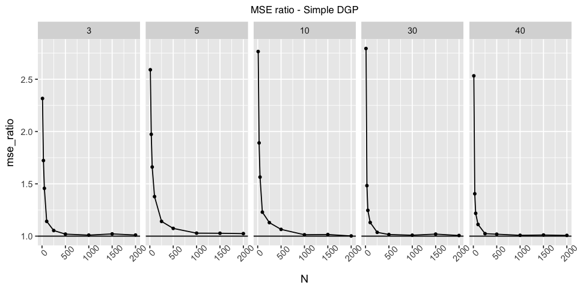

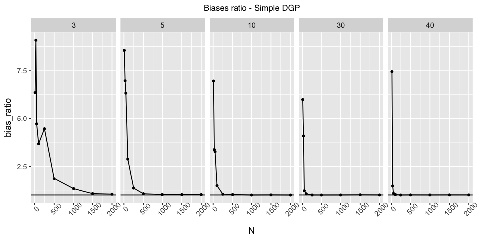

```r
display_mse_ratio(results, gamma=gamma, title="MSE ratio - Simple DGP", with_plotly = FALSE)
display_bias_ratio(results, gamma=gamma, title="Biases ratio - Simple DGP", with_plotly = FALSE)
```

### b. Comparison of FEF and FEVD with Pesaran's DGP in the case of normal errors (case 1)

```r
gamma1=1
gamma2=1
path="/Users/Nicolas/Google Drive/OECD/2016 - Consultant ECO/OECD_SSD_Fixed_Effects"
setwd(path)

results=read.table("simulations_results_dgp1_case1_v2.txt", sep=",")
colnames(results)=c("N", "T", "FEVD_1","FEVD_2", "FEF_1", "FEF_2")

results_z1=results[c("N", "T", "FEVD_1", "FEF_1")]
colnames(results_z1)=c("N", "T", "FEVD", "FEF")

results_z2=results[c("N", "T", "FEVD_2", "FEF_2")]
colnames(results_z2)=c("N", "T", "FEVD", "FEF")

describe_data(results)
```

```
The Monte Carlo Simulations replicated 500 times the data and estimations for every (N, T) couple with N in 30 50 100 500 1000 2000 and T in 3 5 10 30 40
```

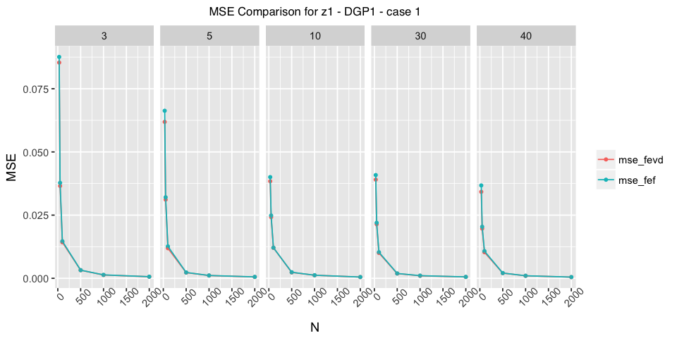

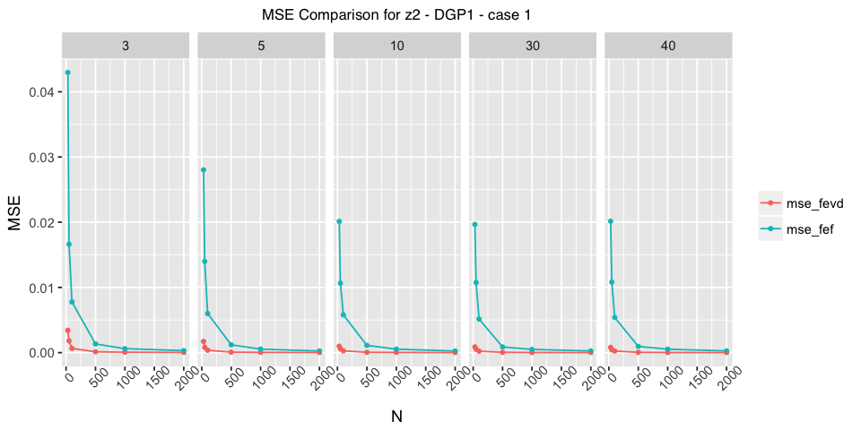

```r
display_mse(results_z1, gamma=gamma1, title="MSE Comparison for z1 - DGP1 - case 1", with_plotly=FALSE)
display_mse(results_z2, gamma=gamma2, title="MSE Comparison for z2 - DGP1 - case 1", with_plotly=FALSE)
```

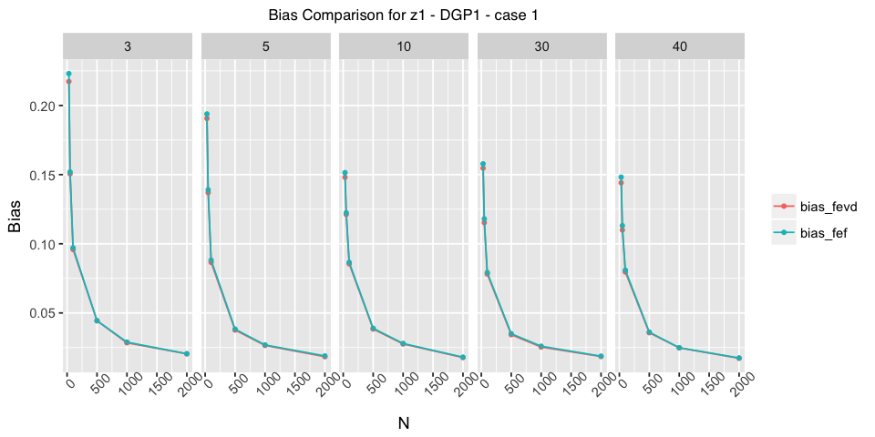

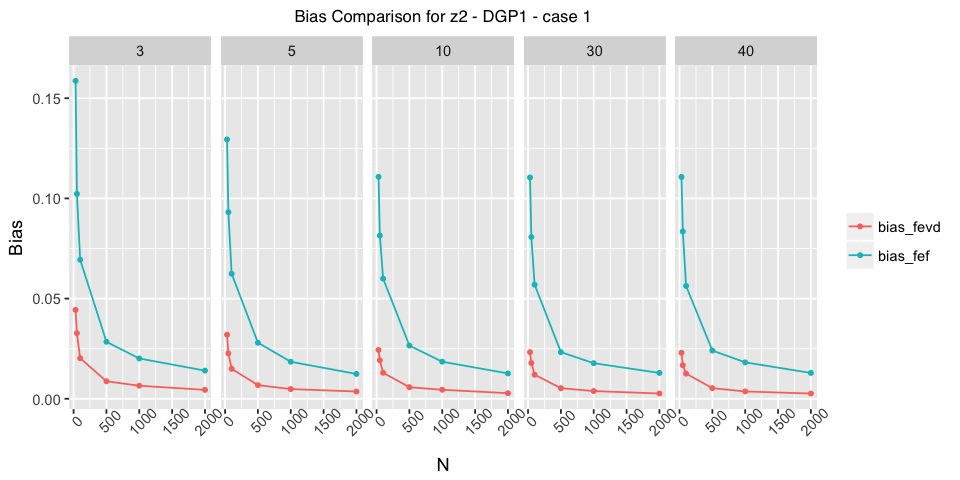

```r
display_bias(results_z1, gamma=gamma1, title="Bias Comparison for z1 - DGP1 - case 1", with_plotly=FALSE)
display_bias(results_z2, gamma=gamma2, title="Bias Comparison for z2 - DGP1 - case 1", with_plotly=FALSE)
```

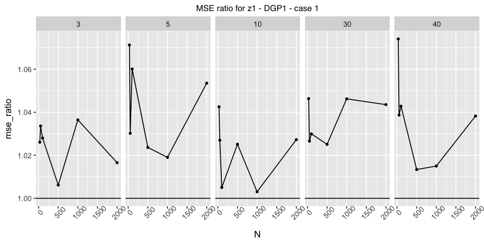

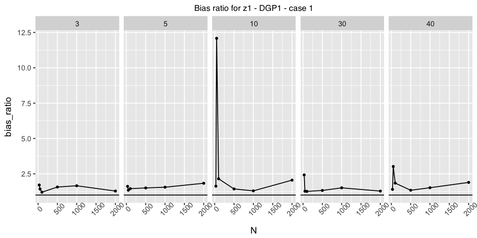

```r
display_mse_ratio(results_z1, gamma=gamma1, title="MSE ratio for z1 - DGP1 - case 1", with_plotly=FALSE)
display_bias_ratio(results_z1, gamma=gamma1, title="Bias ratio for z1 - DGP1 - case 1", with_plotly=FALSE)
```

### c. Comparison of FEF and FEVD with Pesaran's DGP in the case of heteroskedastic errors (case 2)

```r
gamma1=1
gamma2=1
#path="/Users/Nicolas/Simulations_R/"
path="/Users/Nicolas/Google Drive/OECD/2016 - Consultant ECO/OECD_SSD_Fixed_Effects"
setwd(path)

results=read.table("simulations_results_dgp1_case2.txt", sep=",")
colnames(results)=c("N", "T", "FEVD_1","FEVD_2", "FEF_1", "FEF_2")

results_z1=results[c("N", "T", "FEVD_1", "FEF_1")]
colnames(results_z1)=c("N", "T", "FEVD", "FEF")

results_z2=results[c("N", "T", "FEVD_2", "FEF_2")]
colnames(results_z2)=c("N", "T", "FEVD", "FEF")

describe_data(results)
```

```
The Monte Carlo Simulations replicated 500 times the data and estimations for every (N, T) couple with N in 30 50 100 500 1000 2000 and T in 3 5 10 30 40
```

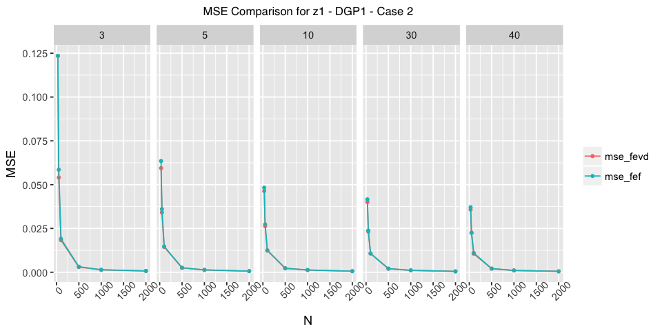

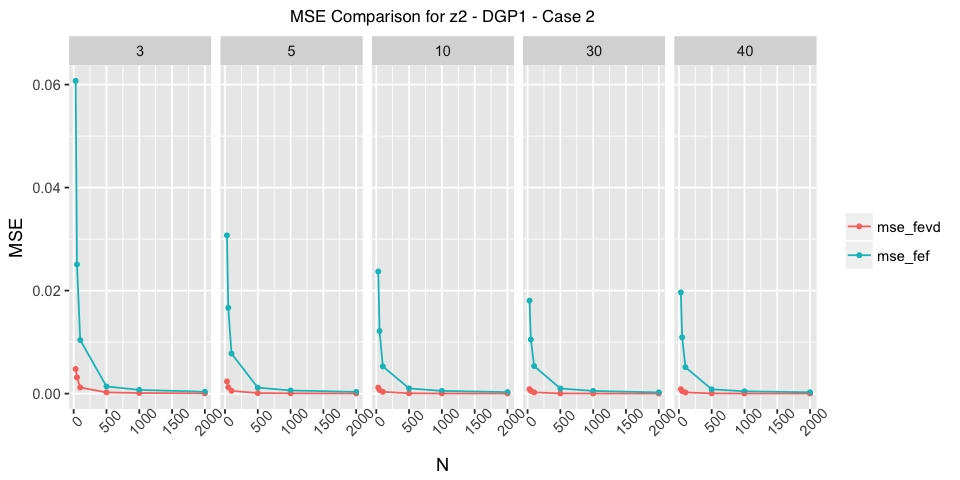

```r
display_mse(results_z1, gamma=gamma1, title="MSE Comparison for z1 - DGP1 - Case 2", with_plotly = FALSE)
display_mse(results_z2, gamma=gamma2, title="MSE Comparison for z2 - DGP1 - Case 2", with_plotly = FALSE)
```

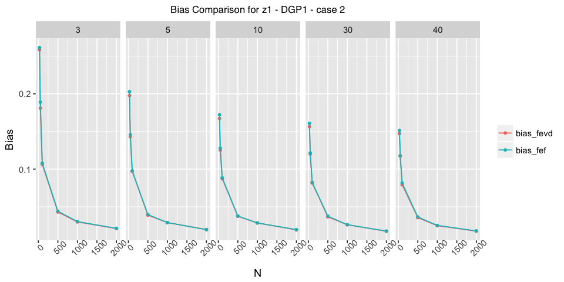

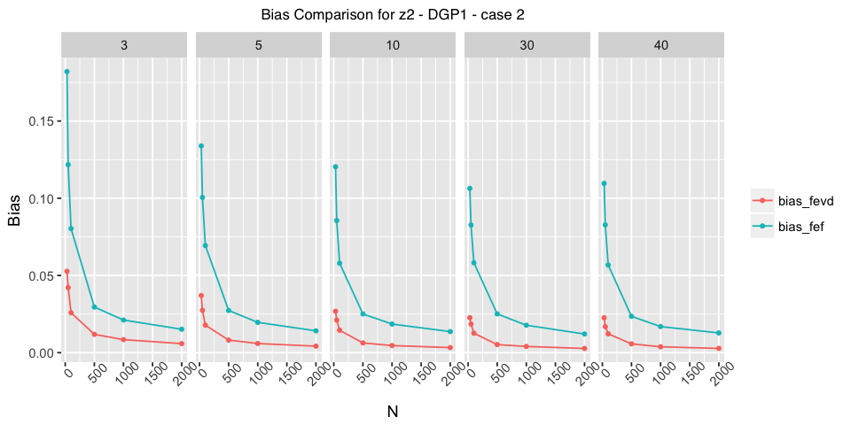

```r
display_bias(results_z1, gamma=gamma1, title="Bias Comparison for z1 - DGP1 - case 2", with_plotly=FALSE)
display_bias(results_z2, gamma=gamma2, title="Bias Comparison for z2 - DGP1 - case 2", with_plotly=FALSE)
```

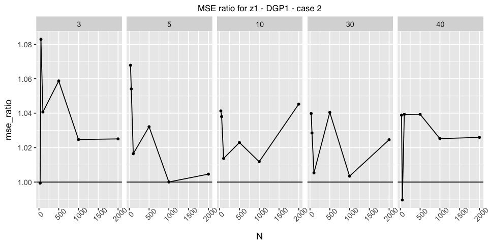

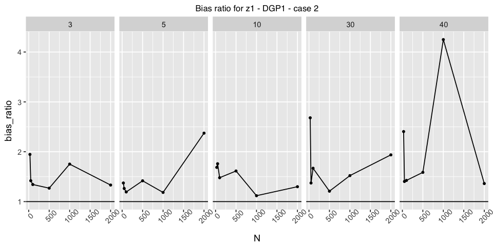

```r
display_mse_ratio(results_z1, gamma=gamma1, title="MSE ratio for z1 - DGP1 - case 2", with_plotly=FALSE)
display_bias_ratio(results_z1, gamma=gamma1, title="Bias ratio for z1 - DGP1 - case 2", with_plotly=FALSE)
```

### d. Comparison of FEF and FEVD with Pesaran's DGP in the case of heteroskedastic and serially correlated errors (case 3)

```r
gamma1=1
gamma2=1
#path="/Users/Nicolas/Simulations_R/"
path="/Users/Nicolas/Google Drive/OECD/2016 - Consultant ECO/OECD_SSD_Fixed_Effects"
setwd(path)

results=read.table("simulations_results_dgp1_case3.txt", sep=",")
colnames(results)=c("N", "T", "FEVD_1","FEVD_2", "FEF_1", "FEF_2")

results_z1=results[c("N", "T", "FEVD_1", "FEF_1")]
colnames(results_z1)=c("N", "T", "FEVD", "FEF")

results_z2=results[c("N", "T", "FEVD_2", "FEF_2")]
colnames(results_z2)=c("N", "T", "FEVD", "FEF")

describe_data(results)
```

```
The Monte Carlo Simulations replicated 500 times the data and estimations for every (N, T) couple with N in 30 50 100 500 1000 2000 and T in 3 5 10 30 40
```

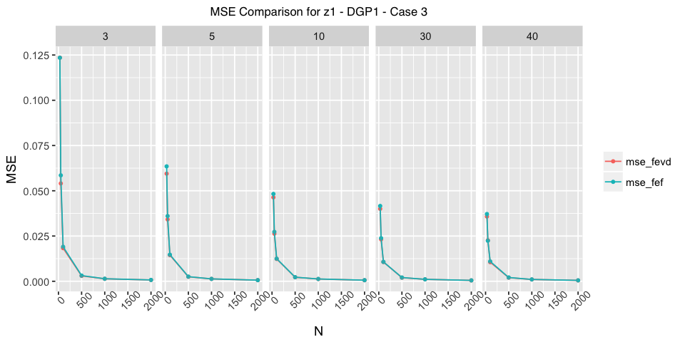

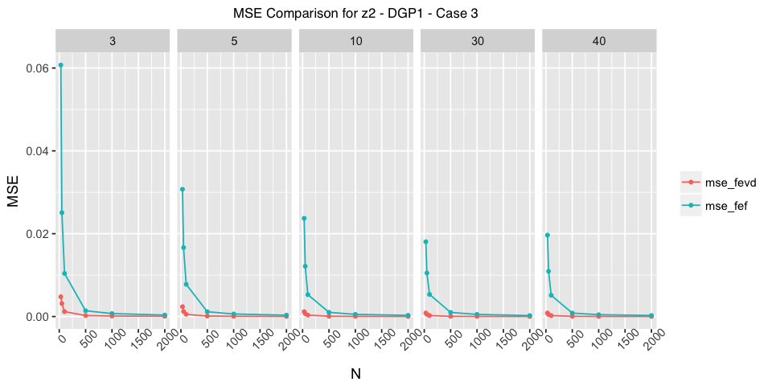

```r
display_mse(results_z1, gamma=gamma1, title="MSE Comparison for z1 - DGP1 - Case 3", with_plotly = FALSE)
display_mse(results_z2, gamma=gamma2, title="MSE Comparison for z2 - DGP1 - Case 3", with_plotly = FALSE)
```

[figure not shown]

[figure not shown]

```r
display_bias(results_z1, gamma=gamma1, title="Bias Comparison for z1 - DGP1 - case 2", with_plotly=FALSE)
display_bias(results_z2, gamma=gamma2, title="Bias Comparison for z2 - DGP1 - case 2", with_plotly=FALSE)
```

[figure not shown]

[figure not shown]

```r
display_mse_ratio(results_z1, gamma=gamma1, title="MSE ratio for z1 - DGP1 - case 2", with_plotly=FALSE)
display_bias_ratio(results_z1, gamma=gamma1, title="Bias ratio for z1 - DGP1 - case 2", with_plotly=FALSE)
```

### e. Comparison of FEF, FEVD, and FEVD with an intercept (Pesarans's DGP - case 1)

```r
gamma1=1
gamma2=1

results=read.table("simulations_results_dgp1_case1_fevd_with.txt", sep=",")
colnames(results)=c("N", "T", "FEVD_1","FEVD_2", "FEF_1", "FEF_2", "FEVD_1_with","FEVD_2_with")

results_z1=results[c("N", "T", "FEVD_1", "FEF_1", "FEVD_1_with")]
colnames(results_z1)=c("N", "T", "FEVD", "FEF", "FEVD_with")

results_z2=results[c("N", "T", "FEVD_2", "FEF_2", "FEVD_2_with")]
colnames(results_z2)=c("N", "T", "FEVD", "FEF", "FEVD_with")

describe_data(results)
```

```
The Monte Carlo Simulations replicated 100 times the data and estimations for every (N, T) couple with N in 30 50 100 500 1000 and T in 5 10 30 40
```

##### In accordance with Pesaran and Zhou, we find that the FEVD with an intercept is equal to the FEF estimator.

```r
display_mse_three(results_z1, gamma=gamma1, title="Comparison of FEVD, FEF and FEVS for z1 with an intercept - case 1", with_plotly=TRUE)
display_mse_three(results_z2, gamma=gamma2, title="Comparison of FEVD, FEF and FEVS for z2 with an intercept - case 1", with_plotly=TRUE)
```

```
No encoding supplied: defaulting to UTF-8.
Success! Modified your plotly here -> https://plot.ly/~NicolasWoloszko/82
```

| N | T | mse_fevd | mse_fef | mse_fevd_with |
| --- | --- | --- | --- | --- |
| 30 | 5 | 0.0425755502 | 0.0439608584 | 0.0439608584 |
| 50 | 5 | 0.0217640484 | 0.0239335739 | 0.0239335739 |
| 100 | 5 | 0.0175115118 | 0.0176162234 | 0.0176162234 |
| 500 | 5 | 0.0023460733 | 0.0023728536 | 0.0023728536 |
| 1000 | 5 | 0.0014214431 | 0.0015036004 | 0.0015036004 |
| 30 | 10 | 0.0411977567 | 0.0460032508 | 0.0460032508 |
| 50 | 10 | 0.0206876382 | 0.0218871007 | 0.0218871007 |
| 100 | 10 | 0.0104192855 | 0.0108387946 | 0.0108387946 |
| 500 | 10 | 0.0022651222 | 0.0023145462 | 0.0023145462 |
| 1000 | 10 | 0.0011864994 | 0.0012007701 | 0.0012007701 |
| 30 | 30 | 0.0307469991 | 0.0324065123 | 0.0324065123 |
| 50 | 30 | 0.0191486729 | 0.0207771039 | 0.0207771039 |
| 100 | 30 | 0.0112964388 | 0.0118210343 | 0.0118210343 |
| 500 | 30 | 0.0018973295 | 0.0019777250 | 0.0019777250 |
| 1000 | 30 | 0.0010419207 | 0.0009912577 | 0.0009912577 |
| 30 | 40 | 0.0335518494 | 0.0395481039 | 0.0395481039 |
| 50 | 40 | 0.0222178366 | 0.0235310734 | 0.0235310734 |
| 100 | 40 | 0.0127677580 | 0.0137887239 | 0.0137887239 |
| 500 | 40 | 0.0017424829 | 0.0018200924 | 0.0018200924 |
| 1000 | 40 | 0.0007413681 | 0.0007980369 | 0.0007980369 |

```
No encoding supplied: defaulting to UTF-8.
Success! Modified your plotly here -> https://plot.ly/~NicolasWoloszko/84
```

| N | T | mse_fevd | mse_fef | mse_fevd_with |
| --- | --- | --- | --- | --- |
| 30 | 5 | 1.366253e-03 | 0.0242376654 | 0.0242376654 |
| 50 | 5 | 7.515535e-04 | 0.0130887613 | 0.0130887613 |
| 100 | 5 | 5.295116e-04 | 0.0071903208 | 0.0071903208 |
| 500 | 5 | 1.016106e-04 | 0.0012284188 | 0.0012284188 |
| 1000 | 5 | 4.675780e-05 | 0.0007577983 | 0.0007577983 |
| 30 | 10 | 1.009564e-03 | 0.0220388759 | 0.0220388759 |
| 50 | 10 | 5.321478e-04 | 0.0091433944 | 0.0091433944 |
| 100 | 10 | 3.263598e-04 | 0.0051309443 | 0.0051309443 |
| 500 | 10 | 6.197188e-05 | 0.0010970841 | 0.0010970841 |
| 1000 | 10 | 2.781988e-05 | 0.0005535092 | 0.0005535092 |
| 30 | 30 | 6.740852e-04 | 0.0141870309 | 0.0141870309 |
| 50 | 30 | 4.075762e-04 | 0.0110083006 | 0.0110083006 |
| 100 | 30 | 2.390738e-04 | 0.0067982629 | 0.0067982629 |
| 500 | 30 | 4.561425e-05 | 0.0009703357 | 0.0009703357 |
| 1000 | 30 | 2.362142e-05 | 0.0004169345 | 0.0004169345 |
| 30 | 40 | 9.867383e-04 | 0.0208319174 | 0.0208319174 |
| 50 | 40 | 4.377455e-04 | 0.0153811579 | 0.0153811579 |
| 100 | 40 | 2.897566e-04 | 0.0050945641 | 0.0050945641 |
| 500 | 40 | 4.367743e-05 | 0.0007798780 | 0.0007798780 |
| 1000 | 40 | 2.346536e-05 | 0.0004976267 | 0.0004976267 |

### f. Dynamic DGP

We now turn to a dynamic model of the following form :

$$y_{it} =\theta \cdot y_{it-1} + \alpha_i + x_{1, it} \beta_1+ x_{2, it} \beta_2 +z_{i} \gamma+ \epsilon_{it}$$

#### DGP1, case 1

```r
path="C:/Users/Woloszko_N/Quantification_Framework/Simulations"
setwd(path)

gamma1=1
gamma2=1

results=read.table("simulations_results_dgp1_case1_dynamic_theta_0_5_deuxiemetest.txt", sep=",")
colnames(results)=c("N", "T", "FEVD_1","FEVD_2", "FEF_1", "FEF_2", "FEVD_1_with","FEVD_2_with")

results_z1=results[c("N", "T", "FEVD_1", "FEF_1", "FEVD_1_with")]
colnames(results_z1)=c("N", "T", "FEVD", "FEF", "FEVD_with")

results_z2=results[c("N", "T", "FEVD_2", "FEF_2", "FEVD_2_with")]
colnames(results_z2)=c("N", "T", "FEVD", "FEF", "FEVD_with")

describe_data(results)
```

```
The Monte Carlo Simulations replicated 500 times the data and estimations for every (N, T) couple with N in 30 50 100 500 and T in 10 30 40
```

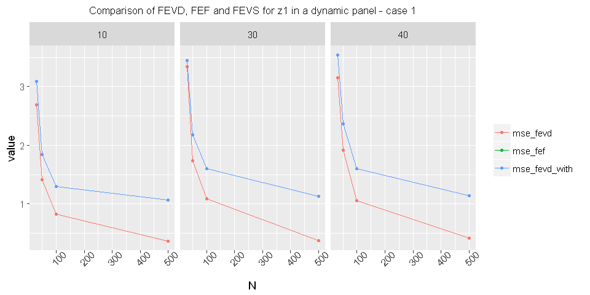

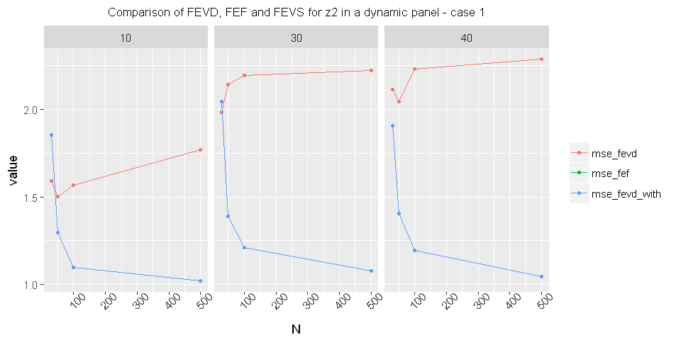

```r
display_mse_three(results_z1, gamma=gamma1, title="Comparison of FEVD, FEF and FEVS for z1 in a dynamic panel - case 1", with_plotly=FALSE)
display_mse_three(results_z2, gamma=gamma2, title="Comparison of FEVD, FEF and FEVS for z2 in a dynamic panel - case 1", with_plotly=FALSE)
```

#### DGP1, case 2

```
The Monte Carlo Simulations replicated 500 times the data and estimations for every (N, T) couple with N in 30 50 100 500 and T in 10 30 40
```

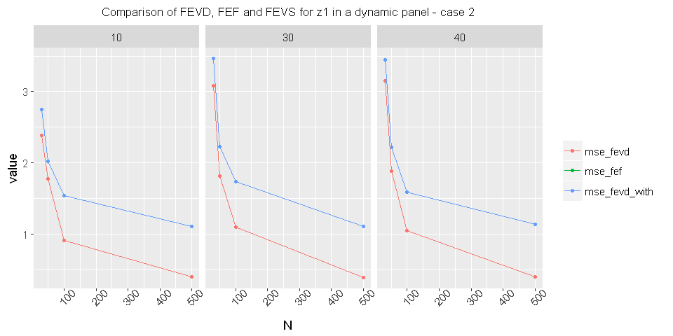

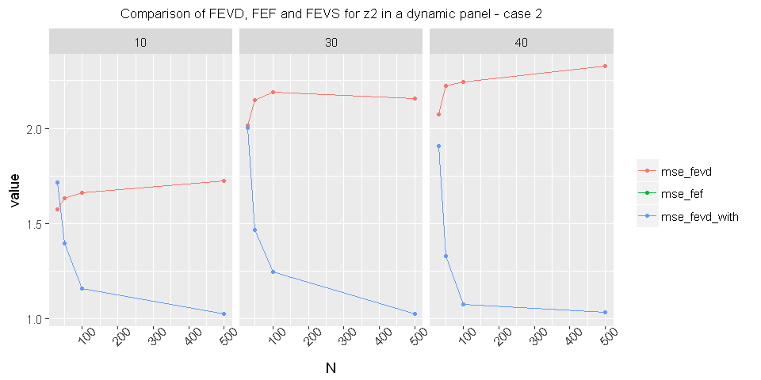

```r
gamma1=1
gamma2=1
path="C:/Users/Woloszko_N/Quantification_Framework/Simulations"
setwd(path)
results=read.table("simulations_results_dgp1_case2_dynamic_theta_0_5t.txt", sep=",")
colnames(results)=c("N", "T", "FEVD_1","FEVD_2", "FEF_1", "FEF_2", "FEVD_1_with","FEVD_2_with")

results_z1=results[c("N", "T", "FEVD_1", "FEF_1", "FEVD_1_with")]
colnames(results_z1)=c("N", "T", "FEVD", "FEF", "FEVD_with")

results_z2=results[c("N", "T", "FEVD_2", "FEF_2", "FEVD_2_with")]
colnames(results_z2)=c("N", "T", "FEVD", "FEF", "FEVD_with")

describe_data(results)

display_mse_three(results_z1, gamma=gamma1, title="Comparison of FEVD, FEF and FEVS for z1 in a dynamic panel - case 2", with_plotly=FALSE)
display_mse_three(results_z2, gamma=gamma2, title="Comparison of FEVD, FEF and FEVS for z2 in a dynamic panel - case 2", with_plotly=FALSE)
```

#### DGP1, case 3

```
The Monte Carlo Simulations replicated 500 times the data and estimations for every (N, T) couple with N in 30 50 100 500 and T in 10 30 40
```

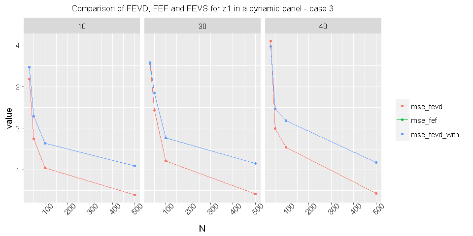

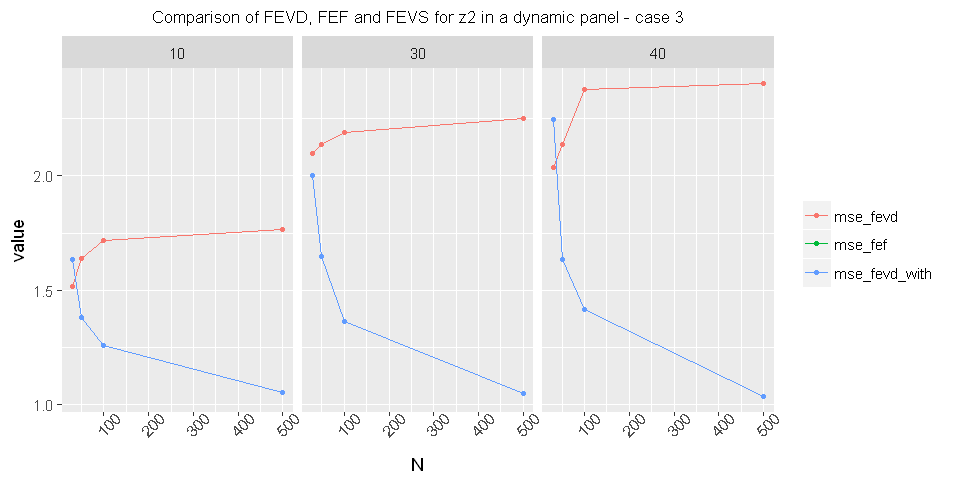

```r
gamma1=1
gamma2=1

results=read.table("simulations_results_dgp1_case3_dynamic_theta_0_5t.txt", sep=",")
colnames(results)=c("N", "T", "FEVD_1","FEVD_2", "FEF_1", "FEF_2", "FEVD_1_with","FEVD_2_with")

results_z1=results[c("N", "T", "FEVD_1", "FEF_1", "FEVD_1_with")]
colnames(results_z1)=c("N", "T", "FEVD", "FEF", "FEVD_with")

results_z2=results[c("N", "T", "FEVD_2", "FEF_2", "FEVD_2_with")]
colnames(results_z2)=c("N", "T", "FEVD", "FEF", "FEVD_with")

describe_data(results)

display_mse_three(results_z1, gamma=gamma1, title="Comparison of FEVD, FEF and FEVS for z1 in a dynamic panel - case 3", with_plotly=FALSE)
display_mse_three(results_z2, gamma=gamma2, title="Comparison of FEVD, FEF and FEVS for z2 in a dynamic panel - case 3", with_plotly=FALSE)
```

# IV. Application to real data

We replicate the procedure used in previous OECD working papers to quantify the impact of structural reforms on MFP. We draw from the interaction framework presented at WP1. We will assess the impacts of slowly time-variant polocy variables using the FEF and FEVD estimators and compare the predictive performances of the two models, using cross-validation. In the next stage, we will use causal cross-validation.

We use three time-invariant variables :

- Transaction_cost_total (Housing market regulation - the higher the more expensive to buy-sell a house)
- rulelaw (Rule of law indicator - the higher the more solid legal institutions)
- PMR_BTE (Barriers to entrepreneurship – the higher the more costly to set up a business)

```r
#install.packages('readstata13', repos='http://cran.rstudio.com/')
library(readstata13)
#f="Application/EstimationData_Replication8_ToNicolas_18Jan2017.dta"
f="//FS-MB-2/SdataECO/units/ssd/_ImpactStructReform/Stata/EstimData/Replication/EstimationData_Replication8_ToNicolas_18Jan2017.dta"
d=read.dta13(f)
colnames(d)[1]='country'
colnames(d)[3]='years'

#colnames(d)
regressand='ert15_64_oecd'
vars=list('ubgr_l', 'hp_unlmp_110', 'avg_twc','edu1', 'og_hp', 'eg', 'NLGXQ')
#vect_vars=c('ubgr_l', 'hp_unlmp_110', 'avg_twc','edu1', 'og_hp', 'eg', 'NLGXQ')
TIVs=list("Transaction_cost_total", "rulelaw", "PMR_BTE")
d=d[c(regressand,'country', 'years', unlist(append(vars, TIVs)))]
#head(d)
#dealing with missing values
d=d[d$year>1980,]
#we replace missing values with the cross-country mean
for(i in 1:ncol(d)){
  d[is.na(d[,i]), i] <- mean(d[,i], na.rm = TRUE)
}
```

```r
real_d=d
```

```r
write.csv(d, "mydata.csv")
```

## 1. Application of the FEF and FEVD estimators to real data

```r
FEF = function (d,regressand, vars, TIVs){
    T=length(unique(d$years))
    N=length(unique(d$country))
    vect_vars=unlist(vars)
    data=pdata.frame(d, c("country","years"))
    data_cmean=aggregate(d[colnames(d)[-2]], by=list(data$country), FUN=function(x) mean(x, na.rm=TRUE))

    fmlaM1=as.formula(paste(regressand, "~", paste(vars, collapse="+"), sep=" "))
    M1=plm(fmlaM1, data=data, effect="individual", model="within")

    coefs=(as.data.frame(M1$coefficients))
    colnames(coefs)='coefficient'


    mat_coef=as.vector(coefs[, 'coefficient'])
    mat_vars=as.matrix(data_cmean[,vect_vars])
    effect_vars=mat_vars %*% diag(mat_coef)
    data_cmean$ui_hat_mean=data_cmean[,regressand]-rowSums(effect_vars)


    fmla=as.formula(paste("ui_hat_mean~", paste(TIVs, collapse="+"), sep=" "))
    M2_fef=lm(fmla, data=data_cmean)
    return(M2_fef)
}

#FEF(d=d,regressand=regressand, vars=vars, TIVs=TIVs)


FEVD = function (d,regressand, vars, TIVs){
    T=length(unique(d$years))
    vect_vars=unlist(vars)
    data=pdata.frame(d, c("country","years"))
    data_cmean=aggregate(d[colnames(d)[-2]], by=list(country=d$country), FUN=function(x) mean(x, na.rm=TRUE))

    fmlaM1=as.formula(paste(regressand, "~", paste(vars, collapse="+"), sep=" "))
    M1=plm(fmlaM1, data=data, effect="individual", model="within")

    coefs=(as.data.frame(M1$coefficients))
    colnames(coefs)='coefficient'

    N=length(unique(d$country))
    mat_coef=as.vector(coefs[, 'coefficient'])
    mat_vars=as.matrix(data_cmean[,vect_vars])
    effect_vars=mat_vars %*% diag(mat_coef)
    data_cmean$ui_hat_mean=data_cmean[,regressand]-rowSums(effect_vars)

    fmla=as.formula(paste("ui_hat_mean~0+", paste(TIVs, collapse="+"), sep=" "))
    M2=lm(fmla, data=data_cmean)

    data$hi=rep(M2$residuals, each=T)
    fmla2=as.formula(paste(regressand, "~hi+", paste(c(vars,TIVs), collapse="+"), sep=" "))
    M3=lm(fmla2, data=data)
    return((M3))
}

#FEVD(d=d,regressand=regressand, vars=vars, TIVs=TIVs)


FEVD_with = function (d,regressand, vars, TIVs){
    T=length(unique(d$years))
    vect_vars=unlist(vars)
    data=pdata.frame(d, c("country","years"))
    data_cmean=aggregate(d[colnames(d)[-2]], by=list(country=d$country), FUN=function(x) mean(x, na.rm=TRUE))

    fmlaM1=as.formula(paste(regressand, "~", paste(vars, collapse="+"), sep=" "))
    M1=plm(fmlaM1, data=data, effect="individual", model="within")

    coefs=(as.data.frame(M1$coefficients))
    colnames(coefs)='coefficient'

    N=length(unique(d$country))
    mat_coef=as.vector(coefs[, 'coefficient'])
    mat_vars=as.matrix(data_cmean[,vect_vars])
    effect_vars=mat_vars %*% diag(mat_coef)
    data_cmean$ui_hat_mean=data_cmean[,regressand]-rowSums(effect_vars)

    fmla=as.formula(paste("ui_hat_mean~", paste(TIVs, collapse="+"), sep=" "))
    M2=lm(fmla, data=data_cmean)

    data$hi=rep(M2$residuals, each=T)
    fmla2=as.formula(paste(regressand, "~hi+", paste(c(vars,TIVs), collapse="+"), sep=" "))
    M3=lm(fmla2, data=data)
    return((M3))
}

#FEVD_with(d=d,regressand=regressand, vars=vars, TIVs=TIVs)
```

```r
UFE=function(d,regressand, vars, TIVs){
    N=length(unique(d$country))
    T=length(unique(d$years))
    TIVs=unlist(TIVs)
    k=length(TIVs)
    data=pdata.frame(d, c("country","years"))

    fmla4=as.formula(paste(regressand,"~", paste(c(vars,TIVs), collapse="+"), sep=" "))
    M4=plm(fmla4, data=data, effect="individual", model="within")

    fe_vect=rep(1, times=N)
    row_1=matrix(c(0,fe_vect, rep(0, length(TIVs))), nrow=1)
    Nu=row_1
    for (z in (TIVs)){
        row_2=matrix(c(0,unlist(d[z])[seq(1, N*T, T)], rep(0, length(TIVs))), nrow=1)
        Nu=rbind(Nu, row_2)
    }

    D=rep(1, times=N*T)
    for (i in 1:N){
        small_vec=(1:N==i)*1
        large_vec=rep(small_vec, each=T)
        D=cbind(D, large_vec)
    }

    Z=d[TIVs]

    DZ=as.matrix(cbind(D, Z))
    Ru=rbind(DZ, Nu)

    N0_row_1=matrix(c(1,rep(0, times=N+k)), nrow=1)#ici on y est allé à l'arrache
    N0=N0_row_1
    for (z in (TIVs)){
        N0_row_2=matrix(rep(0, times=N+k+1), nrow=1)#ici on y est allé à l'arrache
        N0=rbind(N0, N0_row_2)
    }


    #N0_row_1=matrix(c(1,rep(0, times=N+1)), nrow=1)
    #N0_row_2=matrix(rep(0, times=N+2), nrow=1)
    #N0=rbind(N0_row_1, N0_row_2)

    R0=rbind(DZ, N0)
    Rou=solve(t(Ru)%*%Ru)%*%t(Ru)%*%R0

    delta_0=matrix(c(0, fixef(M4)), ncol=1)
    gamma_0=matrix(rep(0, times=length(TIVs)), ncol=1)
    param_0=rbind(delta_0, gamma_0)

    param_u=Rou%*%param_0
    return(tail(param_u, 3))
    #return(param_u)
}
```

*Verification:* We need to verify that

$$N^u \left( \begin{array}{c} \delta^u \\ \gamma^u \end{array} \right) =0$$

```r
N=length(unique(d$country))
T=length(unique(d$years))
TIVs=unlist(TIVs)
k=length(TIVs)
data=pdata.frame(d, c("country","years"))

fmla4=as.formula(paste(regressand,"~", paste(c(vars,TIVs), collapse="+"), sep=" "))
M4=plm(fmla4, data=data, effect="individual", model="within")

fe_vect=rep(1, times=N)
row_1=matrix(c(0,fe_vect, rep(0, length(TIVs))), nrow=1)
Nu=row_1
for (z in (TIVs)){
    row_2=matrix(c(0,unlist(d[z])[seq(1, N*T, T)], rep(0, length(TIVs))), nrow=1)
    Nu=rbind(Nu, row_2)
}

D=rep(1, times=N*T)
for (i in 1:N){
    small_vec=(1:N==i)*1
    large_vec=rep(small_vec, each=T)
    D=cbind(D, large_vec)
}

Z=d[TIVs]

DZ=as.matrix(cbind(D, Z))
Ru=rbind(DZ, Nu)

N0_row_1=matrix(c(1,rep(0, times=N+k)), nrow=1)#ici on y est allé à l'arrache
N0=N0_row_1
for (z in (TIVs)){
    N0_row_2=matrix(rep(0, times=N+k+1), nrow=1)#ici on y est allé à l'arrache
    N0=rbind(N0, N0_row_2)
}


#N0_row_1=matrix(c(1,rep(0, times=N+1)), nrow=1)
#N0_row_2=matrix(rep(0, times=N+2), nrow=1)
#N0=rbind(N0_row_1, N0_row_2)

R0=rbind(DZ, N0)
Rou=solve(t(Ru)%*%Ru)%*%t(Ru)%*%R0

delta_0=matrix(c(0, fixef(M4)), ncol=1)
gamma_0=matrix(rep(0, times=length(TIVs)), ncol=1)
param_0=rbind(delta_0, gamma_0)

param_u=Rou%*%param_0

#dim(Nu)
#dim(param_u)
Nu%*%param_u
```

| 2.778400e-11 |
| --- |
| 2.644054e-10 |
| 9.969003e-11 |
| 1.110374e-10 |

| 2.778400e-11 |
| --- |
| 2.644054e-10 |
| 9.969003e-11 |
| 1.110374e-10 |

```r
#install.packages("stargazer", repos='http://cran.rstudio.com/')
library(stargazer)

fef=FEF(d=d,regressand=regressand, vars=vars, TIVs=TIVs)
fevd=FEVD(d=d,regressand=regressand, vars=vars, TIVs=TIVs)
fevd_with=FEVD_with(d=d,regressand=regressand, vars=vars, TIVs=TIVs)

stargazer(fef, fevd, fevd_with, type="text", column.labels=c('FEF', 'FEVD', 'FEVD with an intercept'))
 #covariate.labels=c("Gross horsepower","Rear axle ratio","Four foward gears",
 #"Five forward gears","Type of transmission (manual=1)"), out="models.htm")
```

```
 Hlavac, Marek (2015). stargazer: Well-Formatted Regression and Summary Statistics Tables.
 R package version 5.2. http://CRAN.R-project.org/package=stargazer
```

[output not shown]

|  | *Dependent variable:* |  |  |
| --- | --- | --- | --- |
|  |  | ert15_64_oecd |  |
|  | FEF | FEVD | FEVD with an intercept |
|  | (1) | (2) | (3) |
| hi |  | 1.000*** | 1.000*** |
|  |  | (0.031) | (0.031) |
| ubgr_l |  | 0.056*** | 0.056*** |
|  |  | (0.013) | (0.013) |
| hp_unlmp_110 |  | 0.067*** | 0.067*** |
|  |  | (0.008) | (0.008) |
| avg_twc |  | -0.133*** | -0.133*** |
|  |  | (0.013) | (0.013) |
| edu1 |  | 0.741*** | 0.741*** |
|  |  | (0.074) | (0.074) |
| og_hp |  | 0.349*** | 0.349*** |
|  |  | (0.074) | (0.074) |
| eg |  | 0.417*** | 0.417*** |
|  |  | (0.032) | (0.032) |
| NLGXQ |  | 0.086** | 0.086** |
|  |  | (0.037) | (0.037) |
| Transaction_cost_total | -0.315 | 0.064 | -0.315*** |
|  | (0.225) | (0.044) | (0.043) |
| rulelaw | 2.375 | 12.316*** | 2.375*** |
|  | (1.406) | (0.389) | (0.264) |
| PMR_BTE | -1.834 | 17.467*** | -1.834*** |
|  | (2.308) | (0.733) | (0.395) |
| Constant | 56.182*** | 0.000 | 56.182*** |
|  | (5.953) | (2.447) | (1.413) |
| Observations | 34 | 1,190 | 1,190 |
| R<sup>2</sup> | 0.296 | 0.732 | 0.732 |
| Adjusted R<sup>2</sup> | 0.226 | 0.729 | 0.729 |
| Residual Std. Error | 4.008 (df = 30) | 3.894 (df = 1178) | 3.894 (df = 1178) |
| F Statistic | 4.204** (df = 3; 30) | 291.792*** (df = 11; 1178) | 291.792*** (df = 11; 1178) |
| *Note:* | *p<0.1; **p<0.05; ***p<0.01 |  |  |

### 2. UFE = FEF ?

We now try and understand why FEF=UFE with artificial data but not with real data. This is strartling. We try and understand the characteristic in the data that cause FEF to be different from UFE. We thus try with various DGPs, including Pesaran's DGP 1 and 2 and their 3 cases (the three cases refer to the type of the error). We also try and produce some irregularities in the data so as to spot the source of the difference between FEF and UFE.

```r
display_comparison=function(d){
    results=as.data.frame(UFE(d=d,regressand=regressand, vars=vars, TIVs=TIVs))
    colnames(results)='UFE'
    results$FEF=FEF(d=d,regressand=regressand, vars=vars, TIVs=TIVs)$coef
    results=results[c(2,3),]
    results$diff=results$UFE-results$FEF
    return(results)
}
```

#### DGP 1

```r
TIVs=list("z1", "z2")
vars=list("x1", "x2")
regressand='y'

d1=DGP1(N=N, T=T, beta1=0.3, beta2=0.4, gamma1=0.5, gamma2=-0.9, case=1)
d2=DGP1(N=N, T=T, beta1=0.3, beta2=0.4, gamma1=0.5, gamma2=-0.9, case=2)
d3=DGP1(N=N, T=T, beta1=0.3, beta2=0.4, gamma1=0.5, gamma2=-0.9, case=3)


display_comparison(d1)
display_comparison(d2)
display_comparison(d3)
```

|  | UFE | FEF | diff |
| --- | --- | --- | --- |
| z1 | 0.4087946 | 0.4087946 | 5.040468e-12 |
| z2 | -1.0323872 | -1.0323872 | 1.152012e-11 |

|  | UFE | FEF | diff |
| --- | --- | --- | --- |
| z1 | 0.3445815 | 0.3445815 | 6.531942e-12 |
| z2 | -0.8782966 | -0.8782966 | 1.855738e-11 |

|  | UFE | FEF | diff |
| --- | --- | --- | --- |
| z1 | -0.1216908 | -0.1216908 | -1.834297e-12 |
| z2 | -1.1383651 | -1.1383651 | -1.029243e-11 |

#### DGP 2

```r
d1=DGP2(N=N, T=T, beta1=0.3, beta2=0.4, gamma1=0.5, gamma2=-0.9, case=1)
d2=DGP2(N=N, T=T, beta1=0.3, beta2=0.4, gamma1=0.5, gamma2=-0.9, case=2)
d3=DGP2(N=N, T=T, beta1=0.3, beta2=0.4, gamma1=0.5, gamma2=-0.9, case=3)


display_comparison(d1)
display_comparison(d2)
display_comparison(d3)
```

|  | UFE | FEF | diff |
| --- | --- | --- | --- |
| z1 | 0.5436067 | 0.5436067 | -1.704192e-13 |
| z2 | -0.5066934 | -0.5066934 | -2.634559e-13 |

|  | UFE | FEF | diff |
| --- | --- | --- | --- |
| z1 | 0.7783019 | 0.7783019 | -5.259126e-13 |
| z2 | -0.4617479 | -0.4617479 | -1.059153e-12 |

|  | UFE | FEF | diff |
| --- | --- | --- | --- |
| z1 | 0.5192261 | 0.5192261 | 5.067058e-12 |
| z2 | -0.6974793 | -0.6974793 | 1.086153e-11 |

#### DGP 3

We code a new DGP to try and see if the structure of the data explain UFE=FEF

```r
d1=DGP3(N=N, T=T, beta1=0.3, beta2=0.4, gamma1=0.5, gamma2=-0.9, case=1)
d2=DGP3(N=N, T=T, beta1=0.3, beta2=0.4, gamma1=0.5, gamma2=-0.9, case=2)
d3=DGP3(N=N, T=T, beta1=0.3, beta2=0.4, gamma1=0.5, gamma2=-0.9, case=3)


display_comparison(d1)
display_comparison(d2)
display_comparison(d3)
```

|  | UFE | FEF | diff |
| --- | --- | --- | --- |
| z1 | 0.4839091 | 0.4839091 | 3.699430e-12 |
| z2 | -0.7224589 | -0.7224589 | -1.076172e-11 |

|  | UFE | FEF | diff |
| --- | --- | --- | --- |
| z1 | 0.5625737 | 0.5625737 | -9.516943e-12 |
| z2 | -0.6918946 | -0.6918946 | 9.811929e-12 |

|  | UFE | FEF | diff |
| --- | --- | --- | --- |
| z1 | 0.03736478 | 0.03736478 | -1.616760e-11 |
| z2 | -0.62601467 | -0.62601467 | 1.266454e-11 |

#### DGP3 + extra variations

```r
d=DGP3(N=N, T=T, beta1=2, beta2=3, gamma1=4, gamma2=5, case=3)
#d$y=1/(d$y)
#d$y=d$y+rpois(n=length(d$y), lambda=3)
d$z1=d$z1+rep(rpois(n=N, lambda=3), each=T)

display_comparison(d)
```

|  | UFE | FEF | diff |
| --- | --- | --- | --- |
| z1 | 0.5591993 | 0.5591993 | -3.217426e-12 |
| z2 | 6.1939182 | 6.1939182 | 2.244605e-11 |

We add a common shock

```r
d[d$years==10, "y"]=d[d$years==10, "y"]+10 #we add a common shock
display_comparison(d)
```

|  | UFE | FEF | diff |
| --- | --- | --- | --- |
| z1 | 0.5637125 | 0.5637125 | -3.228307e-12 |
| z2 | 6.1946326 | 6.1946326 | 2.250111e-11 |

We add a random walk

```r
dim(d)
random_walk=list()
random_walk[1]=0
for (i in 2:dim(d)[1]){
    random_walk[i]=unlist(random_walk[i-1])+rnorm(1,0,1)
}

d$y=d$y+unlist(random_walk)
display_comparison(d)
```

1. 1190

2. 9

|  | UFE | FEF | diff |
| --- | --- | --- | --- |
| z1 | -0.2380354 | -0.2380354 | -3.888417e-12 |
| z2 | 9.2638635 | 9.2638635 | 2.702016e-11 |

#### With real data

```r
#real_d=read.csv("mydata.csv")
regressand='ert15_64_oecd'
vars=list('ubgr_l', 'hp_unlmp_110', 'avg_twc','edu1', 'og_hp', 'eg', 'NLGXQ')
TIVs=list("Transaction_cost_total", "rulelaw", "PMR_BTE")

UFE(d=d,regressand=regressand, vars=vars, TIVs=TIVs)
FEF(d=d,regressand=regressand, vars=vars, TIVs=TIVs)$coef
#display_comparison(real_d)
```

| Transaction_cost_total | -0.5569715 |
| --- | --- |
| rulelaw | -2.1431063 |
| PMR_BTE | -2.1328663 |

**(Intercept)**

56.1815612294873

**Transaction_cost_total**

-0.315464035776967

**rulelaw**

2.37498915127908

**PMR_BTE**

-1.83425774513821

## 2. Comparison of out-of-sample goodness-of-fit

```r
FEF = function (d,regressand, vars, TIVs){
    T=length(unique(d$years))
    data=pdata.frame(d, c("country","years"))
    data_cmean=aggregate(d[colnames(d)[-2]], by=list(data$country), FUN=function(x) mean(x, na.rm=TRUE))
    M1=plm(as.formula(paste(regressand, "~", paste(vars, collapse="+"), sep=" ")), data=data, effect="individual", model="within")
    coefs=(as.data.frame(M1$coefficients))
    colnames(coefs)='coefficient'
    N=length(unique(d$country))
    mat_coef=as.vector(coefs[, 'coefficient'])
    mat_vars=as.matrix(data_cmean[,vect_vars])
    effect_vars=mat_vars %*% diag(mat_coef)
    data_cmean$ui_hat_mean=data_cmean[,regressand]-rowSums(effect_vars)
    M2_fef=lm(as.formula(paste("ui_hat_mean~", paste(TIVs, collapse="+"), sep=" ")), data=data_cmean)
    return(M2_fef)
}

FEVD_with = function (d,regressand, vars, TIVs){
    T=length(unique(d$years))
    data=pdata.frame(d, c("country","years"))
    data_cmean=aggregate(d[colnames(d)[-2]], by=list(country=d$country), FUN=function(x) mean(x, na.rm=TRUE))
    M1=plm(as.formula(paste(regressand, "~", paste(vars, collapse="+"), sep=" ")), data=data, effect="individual", model="within")
    coefs=(as.data.frame(M1$coefficients))
    colnames(coefs)='coefficient'
    N=length(unique(d$country))
    mat_coef=as.vector(coefs[, 'coefficient'])
    mat_vars=as.matrix(data_cmean[,vect_vars])
    effect_vars=mat_vars %*% diag(mat_coef)
    data_cmean$ui_hat_mean=data_cmean[,regressand]-rowSums(effect_vars)
    M2=lm(as.formula(paste("ui_hat_mean~", paste(TIVs, collapse="+"), sep=" ")), data=data_cmean)
    data$hi=rep(M2$residuals, each=T)
    M3=lm(as.formula(paste(regressand, "~hi+", paste(c(vars,TIVs), collapse="+"), sep=" ")), data=data)
    return((M3))
}

FEVD = function (d,regressand, vars, TIVs){
    T=length(unique(d$years))
    data=pdata.frame(d, c("country","years"))
    data_cmean=aggregate(d[colnames(d)[-2]], by=list(country=d$country), FUN=function(x) mean(x, na.rm=TRUE))
    M1=plm(as.formula(paste(regressand, "~", paste(vars, collapse="+"), sep=" ")), data=data, effect="individual", model="within")
    coefs=(as.data.frame(M1$coefficients))
    colnames(coefs)='coefficient'
    N=length(unique(d$country))
    mat_coef=as.vector(coefs[, 'coefficient'])
    mat_vars=as.matrix(data_cmean[,vect_vars])
    effect_vars=mat_vars %*% diag(mat_coef)
    data_cmean$ui_hat_mean=data_cmean[,regressand]-rowSums(effect_vars)
    M2=lm(as.formula(paste("ui_hat_mean~0+", paste(TIVs, collapse="+"), sep=" ")), data=data_cmean)
    data$hi=rep(M2$residuals, each=T)
    M3=lm(as.formula(paste(regressand, "~hi+", paste(c(vars,TIVs), collapse="+"), sep=" ")), data=data)
    return((M3))
}
```

```r
#install.packages("cvTools", repos='http://cran.rstudio.com/')
library(cvTools)

## set up folds for cross-validation
folds <- cvFolds(nrow(d), K = 5, R = 50)

# perform cross-validation for the FEVD estimator
fit_fevd <- FEVD(d=d,regressand=regressand, vars=vars, TIVs=TIVs)
cv_fevd <- cvLmrob(fit_fevd, cost = mape,folds = folds)#, trim = 0.1)
# perform cross-validation for the FEF estimator
fit_fevd_with <- FEVD_with(d=d,regressand=regressand, vars=vars, TIVs=TIVs)
cv_fevd_with <- cvLts(fit_fevd_with, cost = mape,folds = folds)#, trim = 0.1)
# combine results into one object
cvFits <- cvSelect(FEVD = cv_fevd, FEF = cv_fevd_with)
```

[output not shown]

Here are the results of the cross-validation. Cross-validation aims comparing the out-of-sample goodiness of fit of the FEF and FEVD estimators. To do so, we use the K-fold method, that follows the following steps :

- we divide the sample in 5 sub-sample ;
- we pick one of the sub-sample as the test set, merge the 4 others to create the train set, and compare the predictions of our algorithm to the test set
- we do the same 5 times, each sub-sample being used as a test set in turn

When comparing the predictions to the real values, we compute the mean absolute prediction error, that is the average of the absolute difference between the prediction and the true value of the target variable (the emloyment rate, in that case).

The FEF estimator performs slightly better than the FEVD estimator.

```r
cvFits
```

```
5-fold CV results:
   Fit       CV
1 FEVD 2.960842
2  FEF 2.919859

Best model:
   CV
"FEF"
```

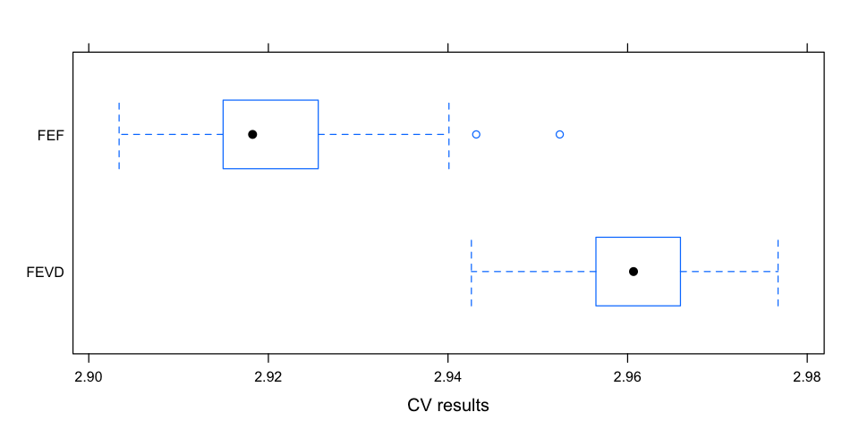

```r
bwplot(cvFits)
```

# (Preliminary) Conclusion

In a simplified non-dynamic framework, cross-validation shows that the FEF estimators yields more predictive accuracy than the FEVD estimator, in accordance with the literature.

# Bibliography

1. Thomas Plümper and Vera E. Troeger, “Efficient Estimation of Time-Invariant and Rarely Changing Variables in Finite Sample Panel Analyses with Unit Fixed Effects,” Political Analysis 15, no. 2 (March 20, 2007): 124–39, doi:10.1093/pan/mpm002.
2. Jushan Bai, “Panel Data Models With Interactive Fixed Effects,” Econometrica 77, no. 4 (July 1, 2009): 1229–79, doi:10.3982/ECTA6135.
3. William Greene, “Fixed Effects Vector Decomposition: A Magical Solution to the Problem of Time-Invariant Variables in Fixed Effects Models?,” Political Analysis 19, no. 2 (2011): 135–146.
4. Jushan Bai, “Fixed-Effects Dynamic Panel Models, a Factor Analytical Method,” Econometrica 81, no. 1 (2013): 285–314.
5. Jushan Bai, “Likelihood Approach to Dynamic Panel Models with Interactive Effects,” Available at SSRN 2332992, 2013, http://papers.ssrn.com/sol3/papers.cfm?abstract_id=2332992.
6. Jushan Bai, Kunpeng Li, and others, “Theory and Methods of Panel Data Models with Interactive Effects,” The Annals of Statistics 42, no. 1 (2014): 142–170.